# R - Licence 3 MIASHS

LOIC RAKOTOSON, loicrakotoson.com

# **Manipulation de données - fonctions usuelles de R**

# 1. **Données chd**

Le fichier **chd.csv** renseigne, sur n = 100 individus, l’âge de l’individu (variable age) et le fait qu’il soit porteur d’une maladie ou non (variable nommée **chd**, codée 1 pour oui, 0 pour non). On s’intéresse à l’influence de l’âge sur le fait d’être porteur ou non de la maladie. L’objet de l’exercice est en particulier de former des classes d’âge (sous forme d’intervalles contigus) et de calculer la proportion de malades dans chacune des classes. On cherche aussi à représenter graphiquement la situation et les résultats obtenus.

Plus généralement, ce type de données peut être utilisé pour essayer de voir si la variable âge (quantitative) permet d’expliquer l’appartenance à l’une des modalités d’une variable binaire (ici variable chd de modalités 1 ou 0). C’est un problème typique de la régression dite logistique. Nous ne rentrons pas ici dans la méthode. Cependant, précisons pour information que la dernière question consiste à appliquer les résultats d’un modèle logistique aux données.

## 1.1 Exploitation des données

1. Importer et calculer le résumé des données.

```r
donnees <- read.csv("chd.csv", sep = ";")
summary(donnees)
```

```
##       age             chd
##  Min.   :20.00   Min.   :0.00
##  1st Qu.:34.75   1st Qu.:0.00
##  Median :44.00   Median :0.00
##  Mean   :44.38   Mean   :0.43
##  3rd Qu.:55.00   3rd Qu.:1.00
##  Max.   :69.00   Max.   :1.00
```

2. Calculer la moyenne de la variable chd. A quoi correspond cette valeur ?

```r
mean(donnees$chd)
```

```
## [1] 0.43
```

3. La variable chd est interprétée comme quantitative : ajouter aux données une colonne appelée *chd.quali* qui contient la conversion de la variable chd en facteur (fonction **factor()**). Recalculer le résumé des données et retrouver ainsi que 43% des individus sont porteurs de la maladie.

```r
chd.quali = factor(donnees$chd, levels = c(0,1), labels = c("sain", "malade"))
donnees = cbind(donnees, chd.quali)
summary(donnees)
```

```
##       age             chd        chd.quali
##  Min.   :20.00   Min.   :0.00   sain  :57
##  1st Qu.:34.75   1st Qu.:0.00   malade:43
##  Median :44.00   Median :0.00
##  Mean   :44.38   Mean   :0.43
##  3rd Qu.:55.00   3rd Qu.:1.00
##  Max.   :69.00   Max.   :1.00
```

4. Calculer la moyenne d’âge d’un individu malade, d’un individu sain.

```r
by(donnees$age,donnees$chd.quali,mean)
```

```
## donnees$chd.quali: sain
## [1] 39.17544
## --------------------------------------------------------
## donnees$chd.quali: malade
## [1] 51.27907
```

5. On se propose de former des classes d’âge puis de calculer la proportion d’individus malades dans chaque classe.
1. Utiliser la fonction **cut()** pour regrouper les valeurs d’âge dans les intervalles suivants :  
   **[20, 29] ]29, 34] ]34, 39] ]39, 44] ]44, 49] ]49, 45] ]54, 59] ]59, 69]**

Indications :  
+ On s’assurera que tous les individus sont bien associés.  
+ On pourra, comme à la question 2, créer une colonne supplémentaire dans le jeu de données, appelée par exemple *age.quali*, qui recevra la classe d’appartenance de chaque individu.

```r
age.quali = cut(donnees$age, b=c(20,29,34,39,44,49,54,59,69), right = T, include.lowest = T)
donnees = cbind(donnees, age.quali)
by(donnees$chd, donnees$age.quali, mean) #moyenne de malades par age.quali
```

```
## donnees$age.quali: [20,29]
## [1] 0.1
## --------------------------------------------------------
## donnees$age.quali: (29,34]
## [1] 0.1333333
## --------------------------------------------------------
## donnees$age.quali: (34,39]
## [1] 0.25
## --------------------------------------------------------
## donnees$age.quali: (39,44]
## [1] 0.3333333
## --------------------------------------------------------
## donnees$age.quali: (44,49]
## [1] 0.4615385
## --------------------------------------------------------
## donnees$age.quali: (49,54]
## [1] 0.625
## --------------------------------------------------------
## donnees$age.quali: (54,59]
## [1] 0.7647059
## --------------------------------------------------------
## donnees$age.quali: (59,69]
## [1] 0.8
```

2. Calculer la proportion d’individus malades dans chaque classe d’âge.

```r
table(donnees$chd.quali, donnees$age.quali) #effectifs par age.quali
```

```
##
##          [20,29] (29,34] (34,39] (39,44] (44,49] (49,54] (54,59] (59,69]
##   sain         9      13       9      10       7       3       4       2
##   malade       1       2       3       5       6       5      13       8
```

## 1.2 Graphe

1. Représenter dans un plan les données d’âge en abscisse et celle de la variable quantitative chd en ordonnée, sans oublier de légender les axes.

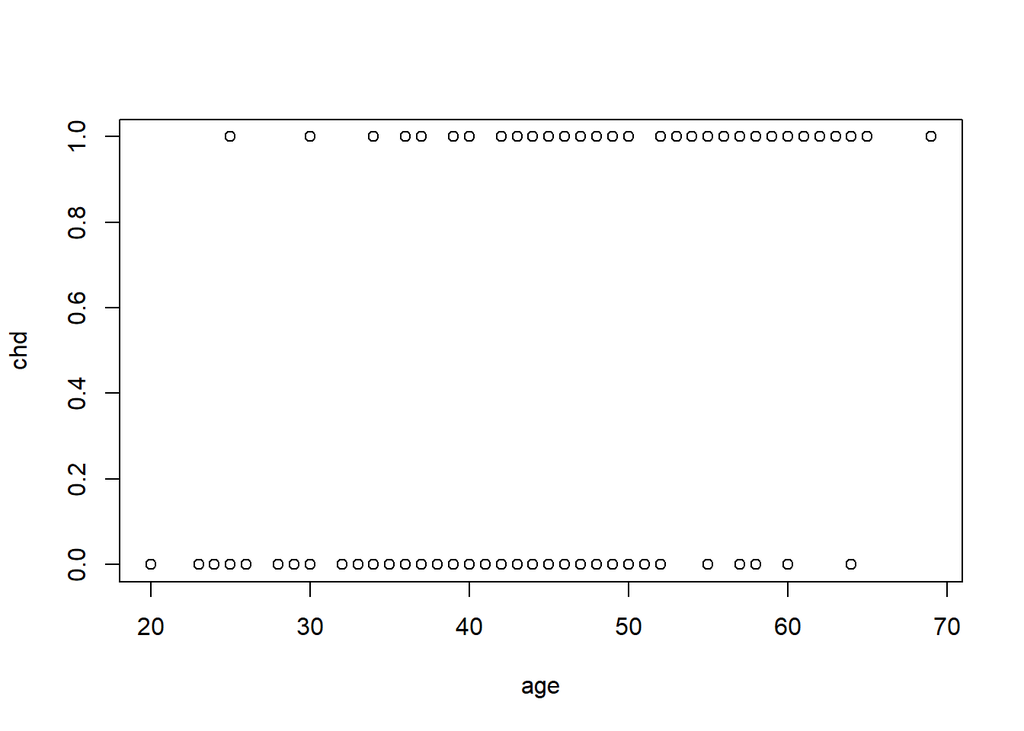

```r
plot(x = donnees$age, y = donnees$chd, xlab = "age", ylab = "chd")
```

2. Ajouter par un trait horizontal en pointillés, la proportion des individus malades (sur l’ensemble des données).

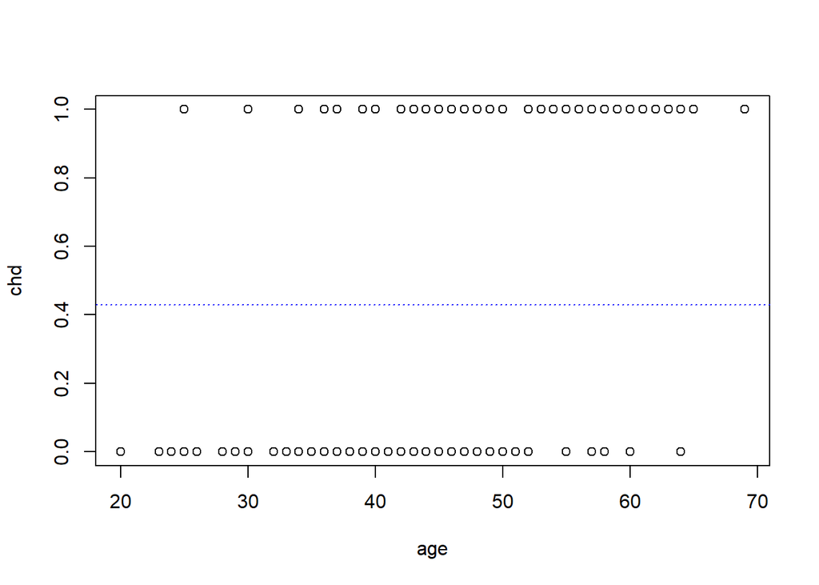

```r
plot(x = donnees$age, y = donnees$chd, xlab = "age", ylab = "chd") # Question 1
abline(h = mean(donnees$chd), col ="blue", lty = "dotted")
```

3. On souhaite ajouter à̀ ce graphe une représentation de la proportion d’individus malades par classe d’âge. Pour cela, on pourra tracer des segments horizontaux de couleur rouge, de bornes correspondantes aux extrémités des classes d’âge, et les placer à la hauteur correspondant à la proportion d’individus malades dans la classe.

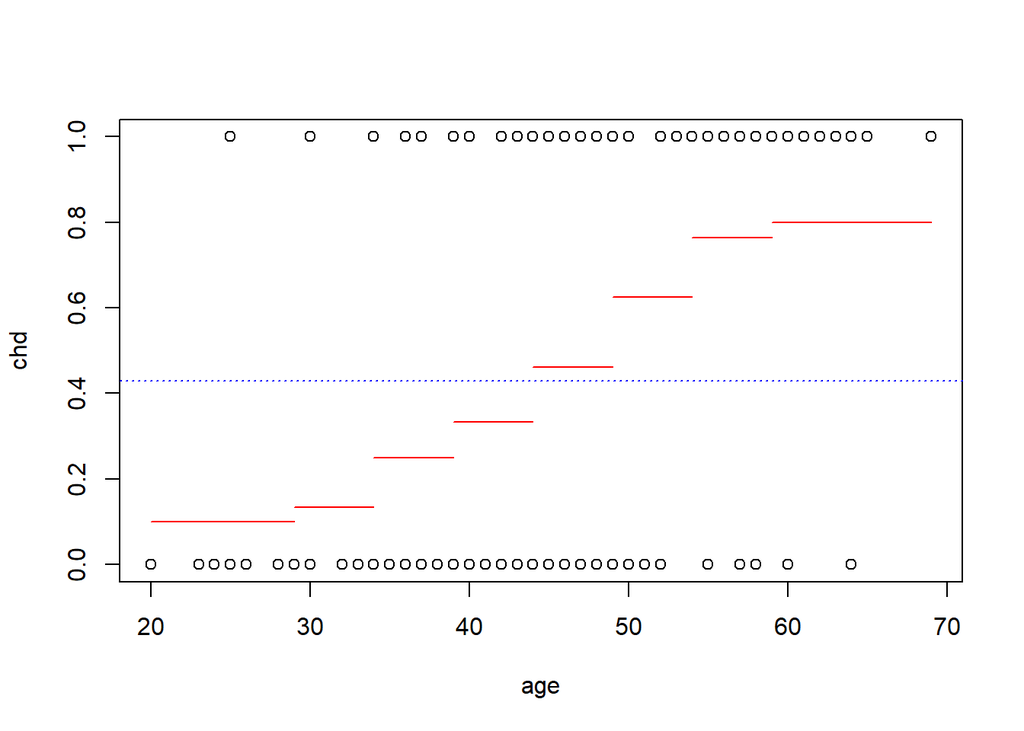

```r
plot(x = donnees$age, y = donnees$chd, xlab = "age", ylab = "chd") # Question 1
abline(h = mean(donnees$chd), col ="blue", lty = "dotted") # Question 2
##proportion de malade par classe d'age
segments(x0 = c(20,29,34,39,44,49,54,59),
         y0 = c(by(donnees$chd, donnees$age.quali, mean)),
         x1 = c(29,34,39,44,49,54,59,69),
         y1 = c(by(donnees$chd, donnees$age.quali, mean)),
         col = "red")
```

4. On considère la fonction f : R → [0, 1] telle que
   $$f(x)=\frac{exp(B_1 + B_2 x)} {1 + exp(B_1 + B_2 x)}$$
   Représenter sur le graphe la courbe de f pour $B_1$= −5, 30 et $B_2$ = 0, 11. Cette fonction est le résultat de l’application d’un modèle logistique aux données : $f(x)$ donne une estimation de la probabilité qu’un individu soit porteur de la maladie à l’âge x.

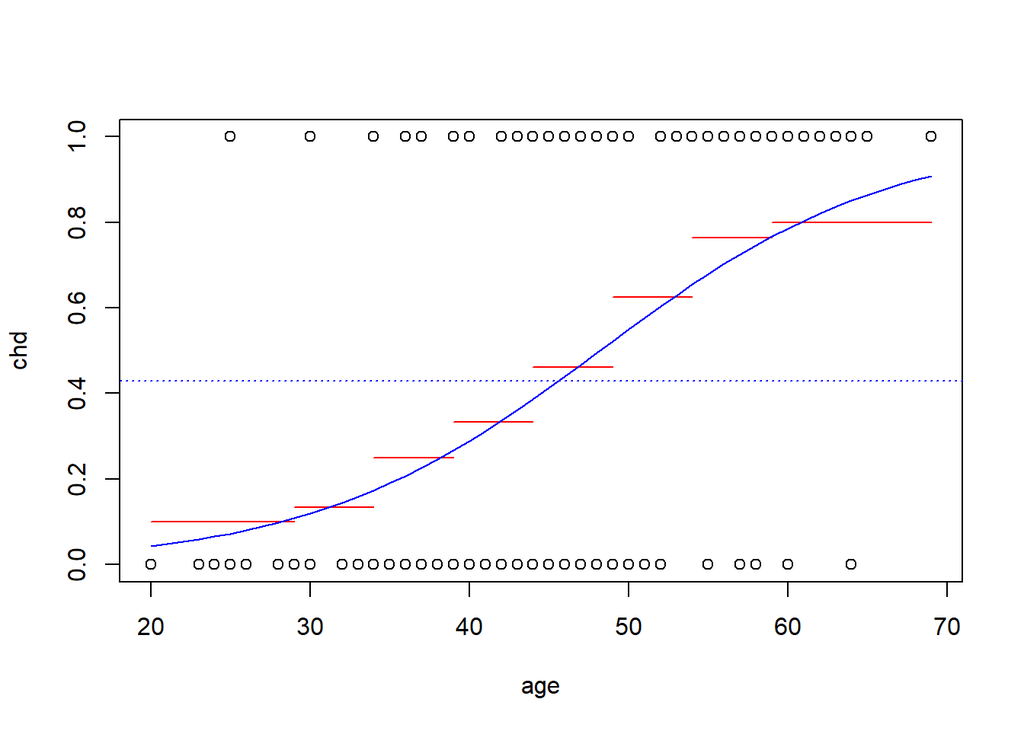

```r
plot(x = donnees$age, y = donnees$chd, xlab = "age", ylab = "chd") # Question 1
abline(h = mean(donnees$chd), col ="blue", lty = "dotted") # Question 2
segments(x0 = c(20,29,34,39,44,49,54,59), y0 = c(by(donnees$chd, donnees$age.quali, mean)), x1 = c(29,34,39,44,49,54,59,69), y1 = c(by(donnees$chd, donnees$age.quali, mean)), col = "red") #Question 3

#_________________________________________________________________
x <- seq(min(donnees$age), max(donnees$age))
lines(x,(exp(-5.3 + 0.11*x))/(1+exp(-5.3 + 0.11*x)), col = "blue")
```

# 2. **Température de surface de l’océan**

Vous disposez de 2 jeux de données de températures de surface de l’océan (en degré Celsius) : données observées et données modélisées. Elles se trouvent dans les fichiers **observations.csv** et **modelise.csv** respectivement. Ces fichiers contiennent des données SST pour 5 régions océaniques proches de la Bretagne : dans la Manche au nord (Manche Nord), et au sud (Manche Sud), en Mer d’Iroise au large (Mer Iroise Zone Large), ou près de la côte (Mer Iroise Zone Côtière) et enfin dans l’Atlantique au large des côtes du Morbihan (Plateau Armoricain). Ces régions sont localisées sur la figure ci-dessous :

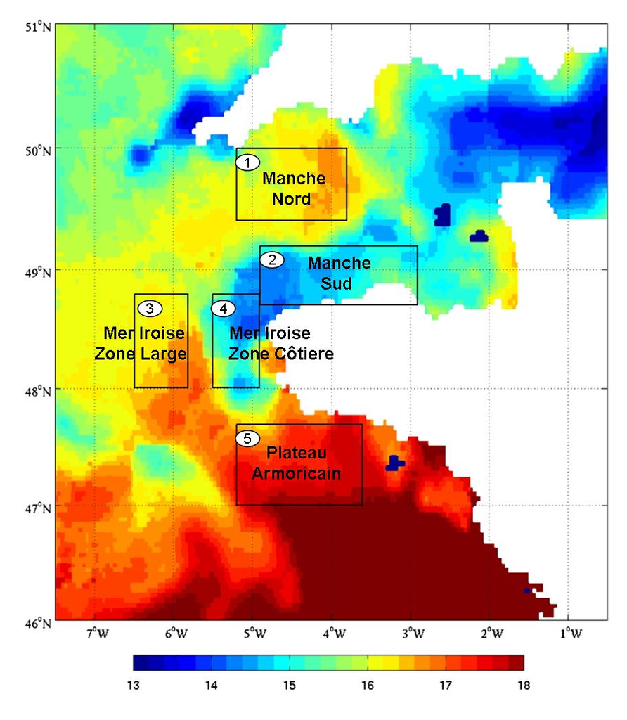

**Données observées** Chaque groupe possède les données de Mer Iroise Zone Large et celles d’une autre région. Il y a 5 colonnes :

- année,
- mois (numéroté de 1 à 12),
- jour (numéroté de 1 à 31),
- SST pour Mer Iroise Zone Large
- SST de l’autre région

Ce sont des données satellites à 5km de résolution moyennée spatialement, au pas de temps journalier de 1986 à 2013.

**Données modélisées** Ce sont des données issues de 3 modèles : CNRM ; MPILR MPIMR à différentes résolutions. Ce sont des valeurs, moyennées sur quelques points qui correspondent à la Mer Iroise Zone Large dans chacun des modèles. Les données sont au pas de temps journalier de 1980 à 2005.

## 2.1 Importation et préparation des données

1. Importer dans R les données. On conservera les colonnes jour, mois et année au format numérique.

```r
observations <- read.csv2("observations.csv")
modelise <- read.csv2("modelise.csv")
```

2. Dans les données d’observations, changer le nom des deux dernières colonnes : *SST MerIroiseZL* en region1 et *SST Plateau Armor* en region2.

```r
names(observations) #pour connaitre les noms de colonnes
```

```
## [1] "annee"            "mois"             "jour"
## [4] "SST_MerIroiseZL"  "SST_PlateauArmor"
```

```r
names(observations)[4] <- "region1"
names(observations)[5] <- "region2"
names(observations) #pour vérifier
```

```
## [1] "annee"   "mois"    "jour"    "region1" "region2"
```

3. Dans les données modélisées, changer le nom des trois dernières colonnes en les nommant : model1, model2 et model3.

```r
names(modelise)
```

```
## [1] "jour"  "mois"  "annee" "CNRM"  "MPILR" "MPIMR"
```

```r
names(modelise)[(ncol(modelise)-2):ncol(modelise)] <- c("model1","model2","model3")
names(modelise)
```

```
## [1] "jour"   "mois"   "annee"  "model1" "model2" "model3"
```

4. Ajouter aux deux data frame de données une colonne intitulée date résultant de la chaîne de caractères obtenue en “collant” les informations d’année, de mois, de jour, dans cet ordre.  
   **NB. La date servira de clé de jointure pour la fusion des tableaux ; il est préférable que le nom de la variable date soit identique dans les deux data frame**

```r
modelise$date <- paste(modelise$jour, modelise$mois, modelise$annee, sep = "/")
observations$date <- paste(observations$jour, observations$mois, observations$annee, sep = "/")
```

5. Dans chaque data frame créer une variable intitulée saison, à 4 modalités,
   - H associée aux mois de décembre, janvier et février
   - P associée aux mois de mars, d’avril et mai
   - E associée aux mois de juin, juillet et août
   - A associée aux mois de septembre, octobre et novembre

```r
#Méthode 1 ___________ Observations Data
observations$saison <- factor(observations$mois, labels = c("H","H",
                                                            "P","P","P",
                                                            "E","E","E",
                                                            "A","A","A",
                                                            "H"))
```

```r
#Méthode 2 ___________ Modelise Data
modelise$saison <- rep("default",nrow(modelise))
modelise$saison[modelise$mois==12 | modelise$mois== 1 | modelise$mois== 2] <- "H"
modelise$saison[modelise$mois== 3 | modelise$mois== 4 | modelise$mois== 5] <- "P"
modelise$saison[modelise$mois== 6 | modelise$mois== 7 | modelise$mois== 8] <- "E"
modelise$saison[modelise$mois== 9 | modelise$mois==10 | modelise$mois==11] <- "A"
modelise$saison <- factor(modelise$saison)
```

## 2.2 Fusion des tableaux

L’opération de fusion de tableau est toujours une opération délicate : il faut avancer avec prudence et autant que possible mettre en place quelques procédures de vérifications. Les dates de mesures ne sont pas identiques dans les deux tableaux. Cependant, les deux tableaux possèdent des dates communes. Nous souhaitons créer un tableau qui comporte toutes les colonnes (i.e. les colonnes des deux tableaux) avec comme informations les lignes correspondant aux dates communes de mesures.

1. L’opérateur **%in%** qui s’applique à deux vecteurs **A** et **B** selon la syntaxe **A *%in%* B** renvoie un vecteur de booléens, de longueur identique à la longueur du vecteur **A**, précisant l’appartenance ou non de chaque coordonnée de **A** à l’ensemble défini par les coordonnées de **B**.

```r
A <- c(1,2,5,30)
B <- 1:10
A %in% B
```

```
## [1]  TRUE  TRUE  TRUE FALSE
```

```r
B %in% A
```

```
##  [1]  TRUE  TRUE FALSE FALSE  TRUE FALSE FALSE FALSE FALSE FALSE
```

2. Déterminer le nombre de lignes dans chacun des deux tableaux. Utiliser l’opérateur défini en question précédente pour déterminer le nombre de dates communes dans les deux tableaux.

```r
nrow(modelise) #nombre de lignes dans modelise
```

```
## [1] 9490
```

```r
nrow(observations) #nombre de lignes dans observations
```

```
## [1] 10220
```

```r
table(modelise$date %in% observations$date) #même nombre de TRUE que:
```

```
##
## FALSE  TRUE
##  2190  7300
```

```r
table(observations$date %in% modelise$date)
```

```
##
## FALSE  TRUE
##  2920  7300
```

3. Faire fusionner les deux tableaux dans un tableau résultat appelé **tab.merge** en utilisant date comme clé de jointure. Assurez-vous que le nombre de lignes est bien celui attendu.

```r
tab.merge <- merge(modelise,observations[,-c(1:3,7)],by="date")
# [,-c(1:3,7)] supprime les redondances des trois premières colonnes (jours, mois, années) et de la septième (saison)
```

4. Identifier quelques lignes des deux tableaux initiaux qui doivent être présentes dans le tableau fusionné. En revenant aux données, vérifier, sur quelques individus, que le tableau fusionné a pris les bonnes informations.
5. Certaines colonnes du tableau fusionné sont redondantes : vérifiez-le puis supprimez les redondances.

```r
#Cette correction a été faite à la question 3
#La suppression de la colonne jour.y de tab.merge s'effectue de la manière suivante:
tab.merge$jour.y <- NULL
```

## 2.3 Statistiques descriptives

Nous travaillons bien sûr désormais sur le tableau fusionné.

1. Présenter les boxplots des 3 variables modélisées toutes dates confondues.

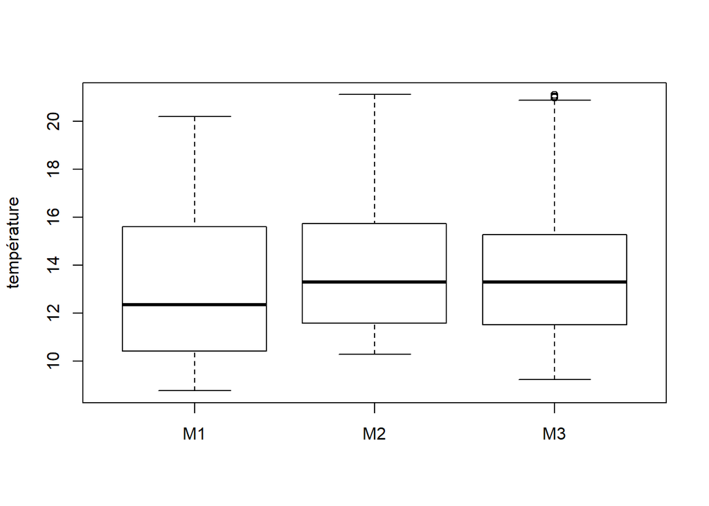

```r
boxplot(tab.merge$model1, tab.merge$model2, tab.merge$model3,
        names = c("M1", "M2", "M3"), ylab = "température")
```

2. Présenter les boxplots des 3 variables modélisées, saison par saison.

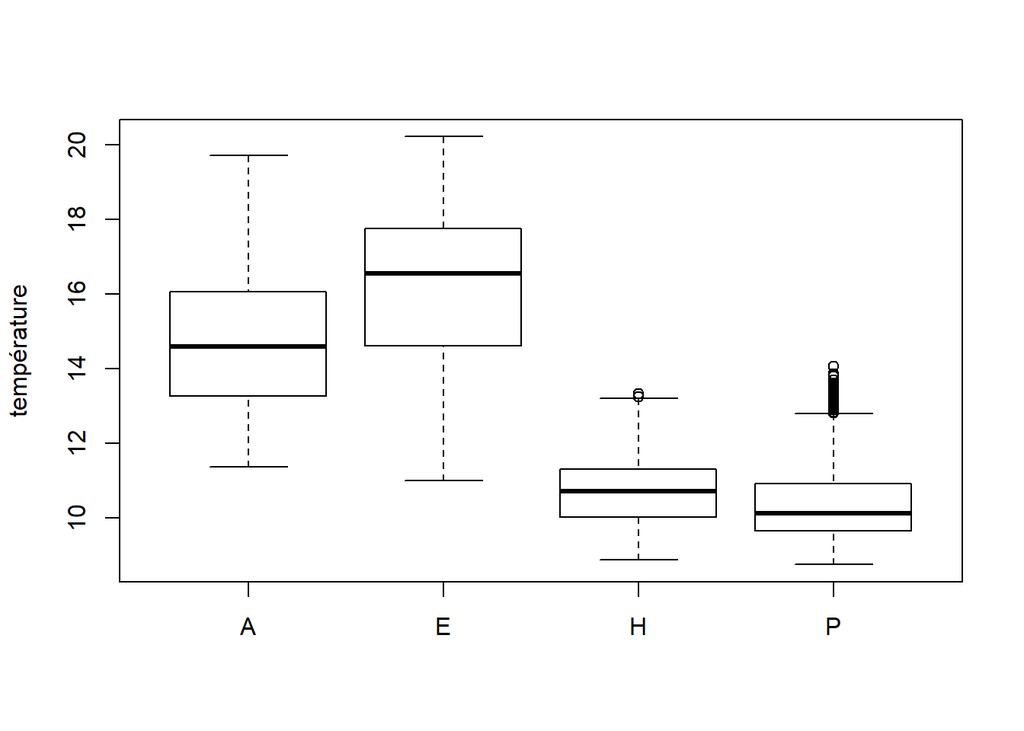

```r
boxplot(model1~saison, data = tab.merge, ylab = "température") # pour le 1er modèle
```

3. Présenter les boxplots des 3 variables modélisées, mois par mois.

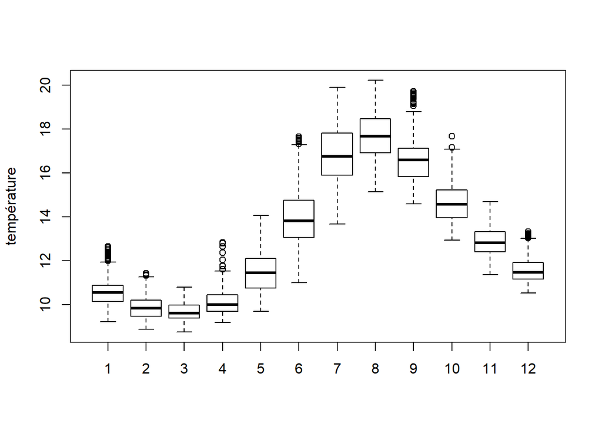

```r
boxplot(model1~mois, data = tab.merge, ylab = "température") # pour le 1er modèle
```

4. Calculer les résumés numériques classiques des variables modélisées toutes dates confondues.

```r
summary(tab.merge$model1) # pour le 1er modèle
```

```
##    Min. 1st Qu.  Median    Mean 3rd Qu.    Max.
##   8.755  10.400  12.358  13.021  15.597  20.211
```

5. Calculer les résumés numériques classiques des variables modélisées saison par saison.

```r
#Méthode 1 _______by() Saison
by(tab.merge$model1, tab.merge$saison, summary) # pour le 1er modèle
```

```
## tab.merge$saison: A
##    Min. 1st Qu.  Median    Mean 3rd Qu.    Max.
##   11.36   13.26   14.59   14.71   16.06   19.72
## --------------------------------------------------------
## tab.merge$saison: E
##    Min. 1st Qu.  Median    Mean 3rd Qu.    Max.
##   11.01   14.62   16.54   16.21   17.74   20.21
## --------------------------------------------------------
## tab.merge$saison: H
##    Min. 1st Qu.  Median    Mean 3rd Qu.    Max.
##   8.876  10.019  10.709  10.715  11.307  13.317
## --------------------------------------------------------
## tab.merge$saison: P
##    Min. 1st Qu.  Median    Mean 3rd Qu.    Max.
##   8.755   9.663  10.134  10.419  10.919  14.064
```

6. Calculer les résumés numériques classiques des variables modélisées mois par mois.

```r
#Méthode 2 _______tapply() summary par mois
tapply(tab.merge$model1, tab.merge$mois, summary) # pour le 1er modèle
```

```
## $`1`
##    Min. 1st Qu.  Median    Mean 3rd Qu.    Max.
##    9.22   10.15   10.56   10.61   10.88   12.66
##
## $`2`
##    Min. 1st Qu.  Median    Mean 3rd Qu.    Max.
##   8.876   9.475   9.836   9.868  10.197  11.433
##
## $`3`
##    Min. 1st Qu.  Median    Mean 3rd Qu.    Max.
##   8.755   9.386   9.618   9.660   9.978  10.792
##
## $`4`
##    Min. 1st Qu.  Median    Mean 3rd Qu.    Max.
##   9.189   9.689  10.001  10.085  10.441  12.830
##
## $`5`
##    Min. 1st Qu.  Median    Mean 3rd Qu.    Max.
##   9.702  10.765  11.444  11.502  12.108  14.064
##
## $`6`
##    Min. 1st Qu.  Median    Mean 3rd Qu.    Max.
##   11.01   13.06   13.82   14.00   14.75   17.66
##
## $`7`
##    Min. 1st Qu.  Median    Mean 3rd Qu.    Max.
##   13.67   15.90   16.75   16.84   17.80   19.89
##
## $`8`
##    Min. 1st Qu.  Median    Mean 3rd Qu.    Max.
##   15.15   16.91   17.68   17.73   18.46   20.21
##
## $`9`
##    Min. 1st Qu.  Median    Mean 3rd Qu.    Max.
##   14.58   15.83   16.58   16.55   17.11   19.72
##
## $`10`
##    Min. 1st Qu.  Median    Mean 3rd Qu.    Max.
##   12.94   13.97   14.57   14.66   15.23   17.66
##
## $`11`
##    Min. 1st Qu.  Median    Mean 3rd Qu.    Max.
##   11.36   12.40   12.81   12.90   13.32   14.68
##
## $`12`
##    Min. 1st Qu.  Median    Mean 3rd Qu.    Max.
##   10.53   11.16   11.47   11.59   11.91   13.32
```

# 3. **Traitement de valeurs manquantes : données bebe**

Le jeu de données **bebe.txt** renseigne des variables mesurées dans une maternité, les individus sont ici les naissances (ou les bébés). Certaines données ne sont pas renseignées. Il s’agit dans cet exercice de repérer les individus pour lesquels au moins une variable n’est pas renseignée dans le but d’éliminer ces individus avant analyse.

## 3.1 Importation, prise en main des données

1. Importer les données.

```r
bebe <- read.csv("bebe.txt", sep=";")
```

2. Calculer le résumé des données. Quelles informations donne la fonction **summary()** quant aux valeurs manquantes ?

```r
summary(bebe) # summary() donne le nombre de NA
```

```
##      Nbsem         Sexe        PoidsBB        TailleBB    PoidsPlacenta
##  Min.   :33.00   F   :242   Min.   :1810   Min.   :42.0   Min.   : 210.0
##  1st Qu.:39.00   M   :255   1st Qu.:3030   1st Qu.:48.0   1st Qu.: 510.0
##  Median :40.00   NA's:  1   Median :3300   Median :50.0   Median : 572.5
##  Mean   :39.53              Mean   :3303   Mean   :49.4   Mean   : 593.8
##  3rd Qu.:40.00              3rd Qu.:3588   3rd Qu.:51.0   3rd Qu.: 662.5
##  Max.   :43.00              Max.   :5030   Max.   :56.0   Max.   :1200.0
##                                            NA's   :10     NA's   :30
##     Operant    JourNaiss    SitMat     AgedelaMere      NaissMere
##  Medecin:134   diM:67    celiba: 43   Min.   :19.00   Min.   :50.00
##  SF     :364   jeu:87    conc  :160   1st Qu.:26.00   1st Qu.:63.00
##                lun:66    Mariee:286   Median :28.00   Median :66.00
##                Mar:73    NA's  :  9   Mean   :28.58   Mean   :65.42
##                Mer:51                 3rd Qu.:31.00   3rd Qu.:68.00
##                saM:72                 Max.   :44.00   Max.   :75.00
##                ven:82
##     TailMere       PoidsMere        Agedupere        NaisPere
##  Min.   :145.0   Min.   : 36.00   Min.   :21.00   Min.   :41.00
##  1st Qu.:159.0   1st Qu.: 50.00   1st Qu.:28.00   1st Qu.:59.00
##  Median :163.0   Median : 56.00   Median :30.00   Median :64.00
##  Mean   :162.9   Mean   : 57.61   Mean   :31.53   Mean   :62.47
##  3rd Qu.:167.0   3rd Qu.: 62.00   3rd Qu.:35.00   3rd Qu.:66.00
##  Max.   :186.0   Max.   :117.00   Max.   :53.00   Max.   :73.00
##  NA's   :66      NA's   :39       NA's   :8       NA's   :8
##     TailPere       PoidsPere        NbGrossess       NbEnfants
##  Min.   :158.0   Min.   : 48.00   Min.   : 1.000   Min.   : 1.000
##  1st Qu.:171.0   1st Qu.: 65.00   1st Qu.: 1.000   1st Qu.: 1.000
##  Median :175.0   Median : 72.00   Median : 2.000   Median : 2.000
##  Mean   :175.7   Mean   : 74.33   Mean   : 2.226   Mean   : 1.847
##  3rd Qu.:180.0   3rd Qu.: 80.00   3rd Qu.: 3.000   3rd Qu.: 2.000
##  Max.   :194.0   Max.   :710.00   Max.   :13.000   Max.   :11.000
##  NA's   :75      NA's   :76       NA's   :25       NA's   :26
##      NbIVG             NbFC             TypeAllait       ModeAccouc
##  Min.   :0.0000   Min.   :0.0000   Artificiel:313   Autre     :  4
##  1st Qu.:0.0000   1st Qu.:0.0000   Maternel  :182   Cesarienne: 76
##  Median :0.0000   Median :0.0000   NA's      :  3   forceps   : 39
##  Mean   :0.1423   Mean   :0.1687                    VBS       :379
##  3rd Qu.:0.0000   3rd Qu.:0.0000
##  Max.   :2.0000   Max.   :5.0000
##  NA's   :6        NA's   :6
##       ModeTravai  Peridurale   DureeTrava        IMCMere      PoidsQuart
##  arti      : 67   non :156   Min.   : 0.000   Min.   :15.24   P1:126
##  autre     :  6   oui :338   1st Qu.: 3.000   1st Qu.:19.27   P2:125
##  Cesarienne: 31   NA's:  4   Median : 5.000   Median :20.83   P3:122
##  ocytosine : 51              Mean   : 5.682   Mean   :21.69   P4:125
##  spontane  :334              3rd Qu.: 7.000   3rd Qu.:23.01
##  NA's      :  9              Max.   :60.000   Max.   :48.70
##                              NA's   :1        NA's   :69
```

3. Paramétrer convenablement l’appel de la fonction **mean()** de sorte à calculer la taille moyenne d’un bébé.

```r
mean(bebe$TailleBB, na.rm = T) # sans considérer les NA ou
```

```
## [1] 49.40061
```

```r
mean(na.omit(bebe$TailleBB)) # en supprimant les lignes avec NA
```

```
## [1] 49.40061
```

## 3.2 Repérage des individus non totalement renseignés

1. Combien y-a-t’il de données manquantes ?

```r
table(is.na(bebe)) # nombre de TRUE ou
```

```
##
## FALSE  TRUE
## 12975   471
```

```r
sum(is.na(bebe)) # somme des TRUE
```

```
## [1] 471
```

2. En combinant les fonctions **is.na()**, **which()** *(préciser le paramètre arr.ind)* et **unique()**, déterminer les individus non totalement renseignés.

```r
#Méthode 1____________ partie de data frame
manque <- unique( bebe [which(is.na(bebe), arr.ind = T) [,1] ,] )
```

3. Retrouver le résultat précédent au moyen d’une boucle sur les colonnes du tableau.

```r
#Méthode 2____________ boucle for et conditionnelle if
manque <- data.frame() # data frame de réception
for (i in 1:ncol(bebe)) {
  if ( length( which( is.na(bebe[,i]) ) ) > 0 ){
    manque <- unique( rbind( manque, bebe[ which( is.na(bebe[,i]) ),]) )
  }
}
```

## 3.3 Export des données “nettoyées”

Etant donné le grand nombre d’individus concernés, les enlever serait sans trop doute trop radical. Mais pour l’exercice, nous construisons un jeu de données “nettoyé” et l’exportons.

1. Créer le tableau regroupant les individus totalement renseignés en utilisant les résultats obtenus.

```r
#Méthode 1____________ suppression par ligne
newBebe <- bebe[ - as.integer(row.names(manque)),]
```

2. Obtenir le même tableau de manière directe en utilisant la fonction **na.omit()**.

```r
#Méthode 2____________ suppression des lignes contenant NA
newBebe <- na.omit(bebe)
```

3. Exporter le tableau ainsi nettoyé au moyen de la fonction **write.table()**.

```r
write.table(newBebe, "newBebe.txt")
```

# **Statistique inférentielle**

# 4. **Simulation avec R**

En statistique inférentielle, on est amené à examiner les propriétés théoriques d’estimateurs (i.e. de variables aléatoires fonction des données) pour juger de leur capacité à bien estimer, dans le cadre de l’estimation paramétrique par exemple, le(s) paramètre(s) inconnu(s) de la loi postulée par le modèle. Ainsi, si on prouve qu’un estimateur a de bonnes propriétés (consistance, faible biais, faible variance…), on a une plus grande confiance en l’estimation du paramètre, estimation qui correspond à la seule réalisation de cette variable aléatoire dont on dispose.

Cependant, étudier les propriétés de telles variables n’est pas toujours simple. En outre, dans certains cas, il peut être utile de tenter de vérifier empiriquement ces propriétés avant de se lancer dans leur étude théorique.

Le logiciel R intègre ainsi un générateur de nombres aléatoires. Plusieurs fonctions prédéfinies permettent ainsi de générer des nombres aléatoires selon la loi usuelle souhaitée. Nous les utilisons dans cette section pour illustrer deux résultats fondateurs en probabilité (Loi des grands nombres, Théorème central limite) et revenir sur le sens de quelques éléments classiques en estimation (estimation par intervalles, biais-variance…).

## 4.1 Fonctions de base pour générer des nombres aléatoires

1. Commenter les instructions suivantes:

fonction **sample()**

```r
sample(100) # Tirage sans remise de 100 nombres de 0 à 100.
```

```
##   [1]  69  96  18   5  25  70  44  35  94  36  73 100  31  83  85  42  87
##  [18]  53  29  84  33  20  15  19  17   7  97   9  56  68  47  51  72  79
##  [35]  75  54  13  28  48  62  23  63  98  60  24  16  11  93  92  37  99
##  [52]  21   1  49  82   6  88  78  86  12  80  76  64  50  30  67  59  46
##  [69]  57  27  77  65  61  38  55  58  40   4  32   8  52  34   2  41  45
##  [86]  22  39   3  89  74  14  43  91  71  95  81  90  26  66  10
```

```r
table(sample(x=1:10, size=100, replace=T)) # Tirage de 100 nombres de 1 à 10 avec remise.
```

```
##
##  1  2  3  4  5  6  7  8  9 10
##  5  5 14 11  9  7 12 11 12 14
```

fonction **rbinom()**

```r
rbinom(n = 10, size = 3, prob = 0.5) # échantillon de taille 10 d'une loi binomiale B(3, 0.5)
```

```
##  [1] 1 1 1 1 1 1 1 1 2 2
```

```r
rbinom(n = 10, size = 5, prob = 0.2) # échantillon de taille 10 d'une loi binomiale B(5, 0.2)
```

```
##  [1] 2 0 2 1 2 0 1 1 1 2
```

fonction **rnorm()**

```r
rnorm(n = 10, mean = 0, sd = 1) # échantillon de taille 10 d'une loi normale N(0, 1)
```

```
##  [1] -0.2608559  0.6361034 -1.1100786 -0.8533597 -0.4929098  0.0651017
##  [7] -0.7217046  0.6159144 -0.0399625  0.2532043
```

```r
rnorm(n = 10, mean = 2, sd = 5) # échantillon de taille 10 d'une loi normale N(2, 5)
```

```
##  [1]  5.068334 -1.291769  1.799393  2.627012  4.870504  2.034627  3.408188
##  [8] -6.012386 -2.907212  6.602505
```

fonction **runif()**

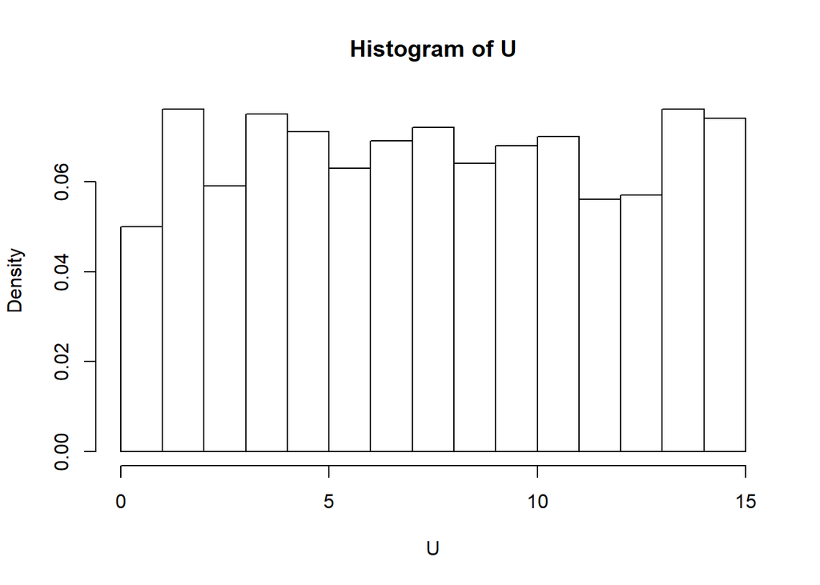

```r
U <- runif(n = 1000, min = 0, max = 15)
hist(U, freq = F) # histogramme d'une loi uniforme d'échantillon de taille 1000
```

2. Générer des nombres aléatoires en utilisant les fonctions **rpois()** puis **rexp()**.

```r
rpois(n = 10, lambda = 5) # échantillon de taille 10 d'une loi Poisson P(5)
```

```
##  [1] 9 5 5 8 7 4 4 8 8 4
```

```r
rexp(n = 10, rate = 5) # échantillon de taille 10 d'une loi exponentielle E(5)
```

```
##  [1] 0.13569782 0.06296473 0.01579957 0.87295660 0.28097965 0.47324670
##  [7] 0.11502569 0.01499553 0.08379422 0.18605910
```

3. Générer n = 1000 nombres aléatoires suivant une loi $N (0, 1)$.
1. Représenter un histogramme de la distribution des valeurs.

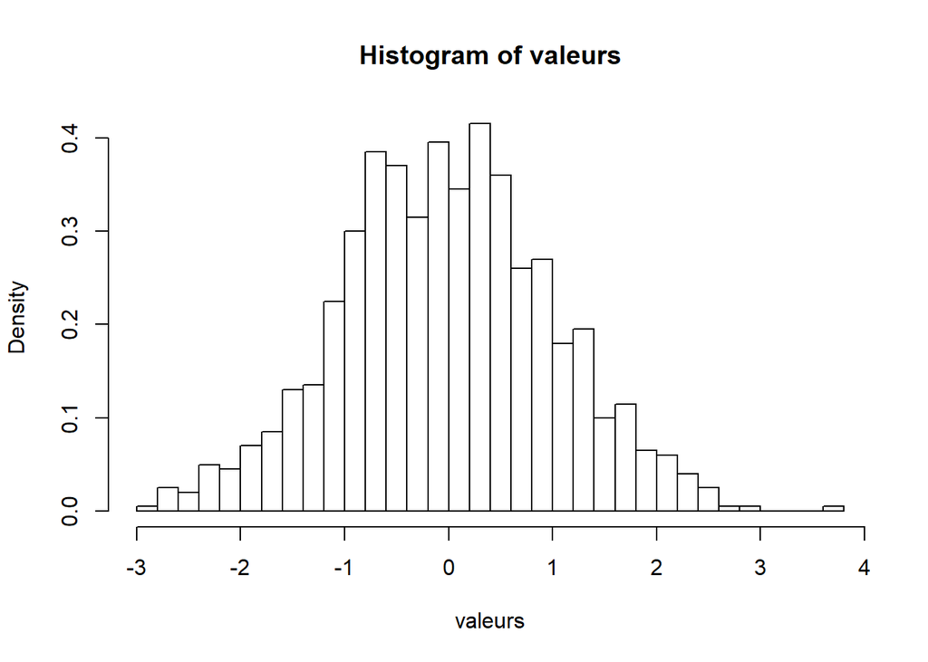

```r
valeurs <- rnorm(1000, 0, 1)
hist(valeurs, freq = F, breaks = 30)
```

2. Au graphe précédent, ajouter la courbe de densité de la loi $N (0, 1)$ (fonctions **dnorm()** et **lines()**).

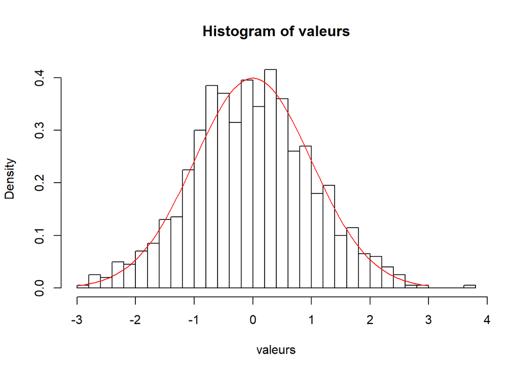

```r
hist(valeurs, freq = F, breaks = 30) # Question a

x <- seq(-3,3, length=100)
y <- dnorm(x,0,1)
lines(x,y,col="red")
```

3. Représenter la fonction de répartition empirique de ces valeurs aléatoires (fonction **ecdf()**).

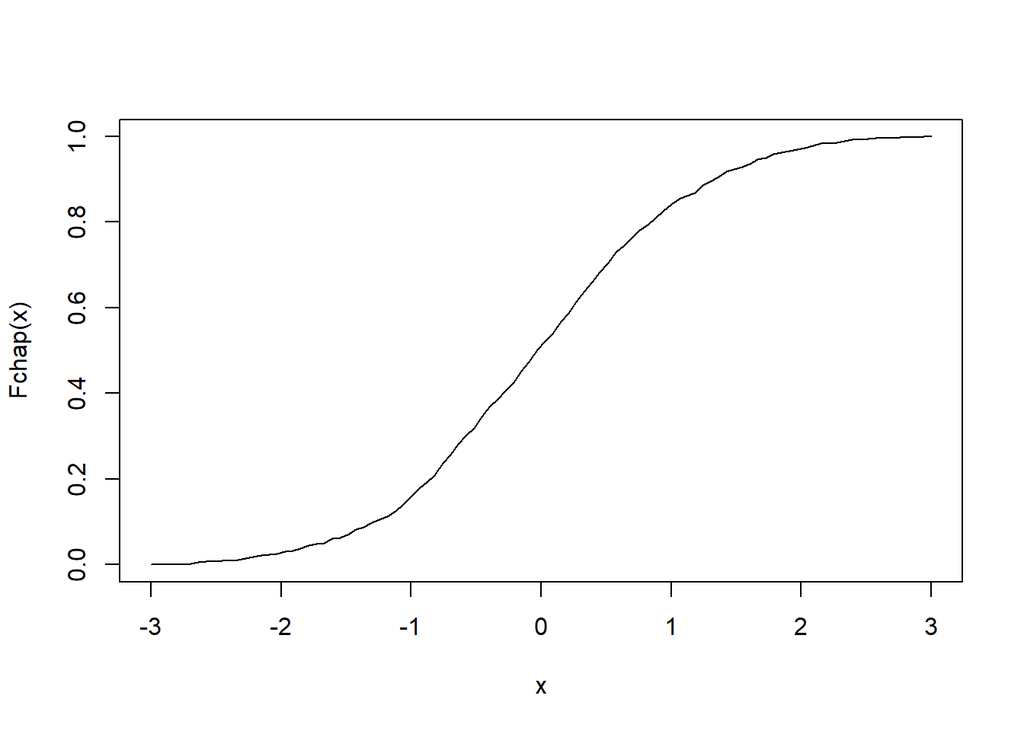

```r
Fchap <- ecdf(valeurs)
plot(x, Fchap(x), type = "l")
```

4. Sur le même graphe, ajouter la courbe de la fonction de répartition de la loi $N (0, 1)$ (fonction **pnorm()**).

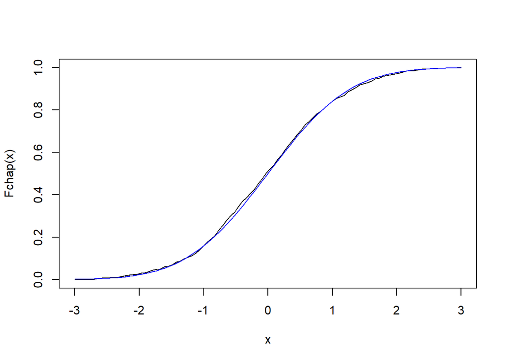

```r
Fchap <- ecdf(valeurs)
plot(x, Fchap(x), type = "l") #Question c

lines(x,pnorm(x,0,1), col = "blue")
```

## 4.2 Génération d’échantillons

Nous venons de voir comment générer un échantillon (par définition un échantillon est aléatoire) selon une loi particulière. On est souvent intéressé par la moyenne d’un échantillon. En composant la fonction **mean()** avec les fonctions de génération des nombres aléatoires vues au-dessus, cela est très simple. Par exemple :  
`mean( rnorm( 10, mean=0, sd=1 ) )`  
On propose dans la suite de générer *K* échantillons de taille *n* selon une loi commune et calculer chacune des *K* moyennes associées, au moyen d’une boucle tout d’abord, puis de manière plus appropriée ensuite.

```r
M <- NULL
K <- 5
n <- 10
for (i in 1:K){
  M[i] <- mean( rnorm(n,0, 1) )
}
print(M)
```

```
## [1]  0.11617175  0.30797111 -0.02895716  0.39349204  0.48478263
```

2. En combinant les fonctions **matrix()** et **apply()**.  
   *valeurs* est un tirage d’échantillon de taille *K* * *n*  
   *M* est une matrice où chaque ligne correspond à un échantillon.  
   On calcule la moyenne par ligne de la matrice.

```r
valeurs <- rnorm(K*n, 0,1)
M <- matrix(valeurs, K, n)
apply( M, 1, mean )
```

```
## [1]  0.4125274  0.0888329  0.6666163 -0.1000189  0.3184577
```

## 4.3 Loi des grands nombres

On rappelle la **loi faible des grands nombres** :
Soit (X<sub>n</sub>)<sub>n∈N</sub>une suite de variables aléatoires d’espérance commune E[X] = µ et de variance commune var(X) = σ<sup>2</sup> . Alors:
$$\forall\epsilon < 0, \hspace{20pt} lim_{n\to\infty} P (|\frac{X_1+...+X_n}{n}-\mu | > \epsilon)=0$$
Autrement-dit, pour un échantillon i.i.d. (c’est le cas courant), la probabilité que la (variable aléatoire) moyenne d’échantillon s’éloigne de plus de ε de l’espérance commune E[X] converge vers 0 quand $n\to\infty$.
Il ne s’agit pas ici de calculer la probabilité en question, mais d’en obtenir une valeur approchée en comptant la proportion des moyennes d’échantillon $\bar{x}=\frac{x_1+...+x_n}{n}$ telles que
$$|\bar{x}-\mu|>\epsilon$$
On prendra les $X_i$ i.i.d. selon une loi normale $\mathcal{N}(\mu, \sigma^2 )$.
1. Proposer une programmation qui permettent de faire varier les constantes (µ, σ, n, ε et *K* le nombre d’échantillons) au clavier et qui compte, parmi les *K* échantillons, la proportion de ceux dont les moyennes $\bar{x}=\frac{x_1+...+x_n}{n}$ vérifient:
$$|\bar{x}-\mu|>\epsilon$$

Déclaration des constantes

```r
n <- 10
K <- 500
mu <- 0
sigma <- 1
epsilon <- 0.2
```

Tirage, avec une boucle, de $K$ echantillons de loi $\mathcal{N}(\mu,\sigma)$ et réception de leur moyenne dans *resultat*

```r
resultat <- rep(0,K)
for (i in 1:K) {
  echantillon <- rnorm( n, mean = mu, sd = sigma)
  resultat[i] <- mean(echantillon)
}
summary(resultat)
```

```
##     Min.  1st Qu.   Median     Mean  3rd Qu.     Max.
## -0.95135 -0.23665 -0.01501 -0.01081  0.20324  1.02282
```

Calcul des pourcentages

```r
sum( resultat > epsilon )/K
```

```
## [1] 0.252
```

2. Faire varier les constantes de sorte à illustrer la loi des grands nombres.
3. Représenter graphiquement la situation.
   - Choix d’une grille de valeur de $n$ (ici **NN**: 10, 50, 100, 200, 500)
   - Initialisation du graphique (entre -1 et 1 sur cette grille de $n$)
   - Pour chaque valeur de $n$, tirage de $K$ = 500 echantillons dont la moyenne est calculée et représentation en *points*
   - Rajout des droites horizontales

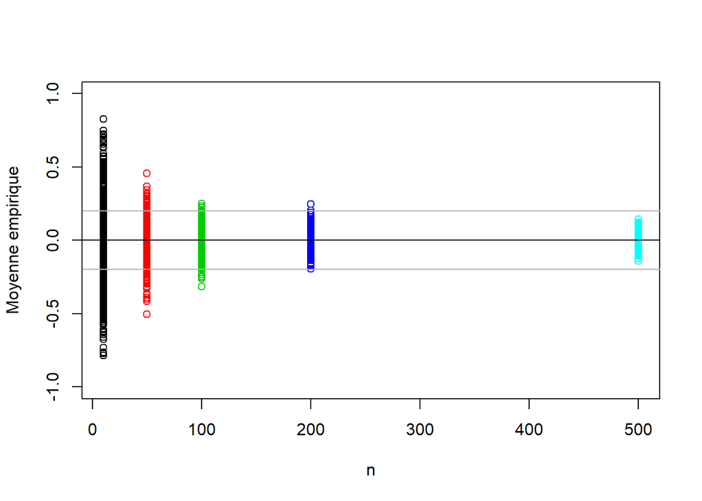

```r
NN <- c( 10, 50, 100, 200, 500)

plot( rep( NN, each=2 ), rep( c( -1, 1 ), length(NN) ), type="n", xlab="n", ylab="Moyenne empirique")

for (n in 1:length(NN) ) {
  resultat <- rep( 0, K )

  for (i in 1:K) {
    echantillon <- rnorm( NN[n], mean = mu, sd = sigma)
    resultat[i] <- mean(echantillon)
  }

  summary (resultat)
  points( rep( NN[n], K ), resultat, col = n )
}


abline(h=c(mu,mu+epsilon,mu-epsilon),col=c("black","grey70","grey70"))
```

**Remarque*** Dans cet exercice, nous admettons que la proportion des moyennes d’échantillons telles que $|\bar{x}-\mu|>\epsilon$ est proche de $P(|\bar{X}-\mu|>\epsilon)$ . Nous l’admettons car c’est un résultat conforme à l’intuition. Cependant sa justification relève… de la loi des grands nombres…

## 4.4 Théorème Central Limite

On rappelle le théorème : Soit ($X_n$) une suite de variables aléatoires i.i.d. selon une loi commune $X$ d’espérance $\mu$ et de variance $\sigma^2$ . Alors :
$$\frac{1}{\sqrt{n}}(\frac{X_1+...X_n - n\mu}{\sigma})\to_{\mathcal{L}}\mathcal{N}(0,1)\hspace{50pt}(1)$$

1. Vérifier que la variable aléatoire dans l’équation $(1)$ peut s’écrire $\frac{\bar{X}-\mu}{\sigma/\sqrt{n}}$
2. En pratique, pour n assez grand, par quelle loi peut-on approcher la loi de $\bar{X}$ ?

#### Illustration avec $X$~ $\mathcal{U}_{[a,b]}$

1. Rappeler les expressions de **E[X]** et **var(X)** pour $X$~ $\mathcal{U}_{[a,b]}$
2. Générer *K* moyennes d’échantillon $X_1$, . . . , $X_n$ avec les $X_i$ i.i.d. selon la loi $\mathcal{U}_{[a,b]}$.

```r
# Affectations paramètres
a <- 0
b <- 1
mu <- (b+a)/2
sigma <- sqrt((b-a)^2/12)
n <- 10
K <- 500

# Tirages des echantillons et calculs de moyenne
echantillon <- matrix( runif( n*K, a, b), nrow = K, ncol = n)
resultat <- apply( echantillon, 1, mean)
```

3. Sur un même graphe représenter la distribution de ces *K* moyennes d’échantillon et la distribution théorique par laquelle on peut l’approcher.

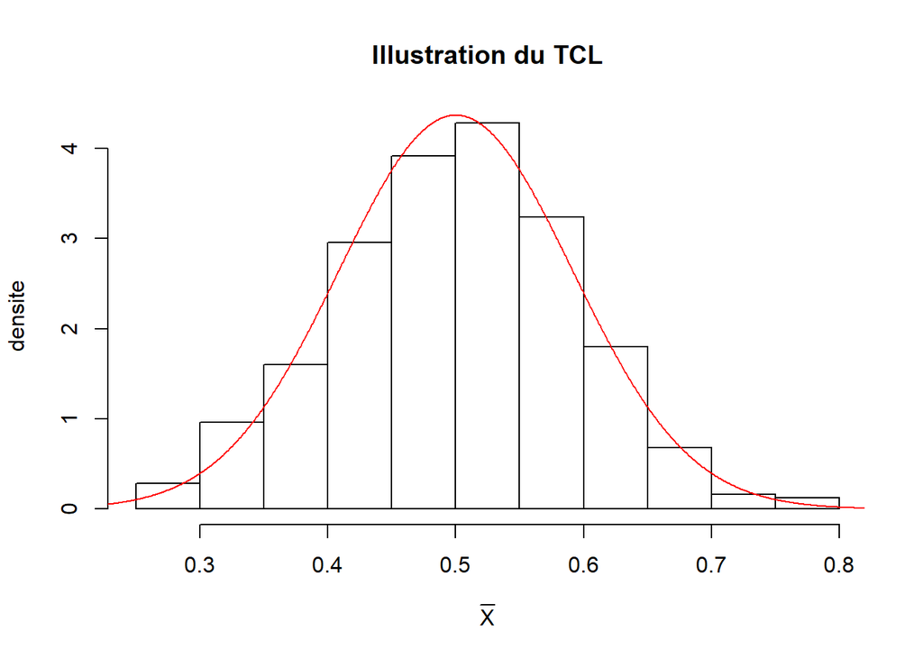

```r
x <- seq ( mu-3.5*sigma/sqrt(n), mu+3.5*sigma/sqrt(n), length = 1000)
y <- dnorm( x, mean = mu, sd = sigma/sqrt(n) )

hist( resultat, freq = F, main = "Illustration du TCL", xlab = expression(bar(X)), ylab = "densite")

lines( x, y, col = "red") # distribution théorique
```

## 4.5 Notion d’intervalle de confiance

### Données *Nile*

Les données Nile sont disponibles sous **R**. Elles donnent la valeur du débit annuel du Nil, entre 1871 et 1970, à Assouan.

1. Quel est le débit moyen, mesuré sur ces 100 années ? Quel est l’écart-type ?

```r
mean(Nile) # débit moyen
```

```
## [1] 919.35
```

```r
sd(Nile) # écart-type
```

```
## [1] 169.2275
```

2. En utilisant la fonction **t.test()**, obtenir un intervalle de confiance pour le débit moyen, au niveau de confiance 95%, au niveau de confiance 99%.

```r
t.test(Nile, conf.level = 0.95)$conf.int
```

```
## [1] 885.7716 952.9284
## attr(,"conf.level")
## [1] 0.95
```

```r
t.test(Nile, conf.level = 0.99)$conf.int
```

```
## [1] 874.904 963.796
## attr(,"conf.level")
## [1] 0.99
```

3. Vérifier que les bornes des intervalles de confiance sont données par:
   $$\bar{x}\pm\frac{\hat{\sigma}}{\sqrt{n}}t_{n-1}(1-\alpha/2)$$

```r
#Pour un niveau de confiance à 95%
#Les bornes sont
inferieur <- mean(Nile) - (sd(Nile) * qt( 0.975, df = length(Nile) - 1) )/sqrt( length(Nile) )
inferieur
```

```
## [1] 885.7716
```

```r
superieur <- mean(Nile) + (sd(Nile) * qt( 0.975, df = length(Nile) - 1) )/sqrt( length(Nile) )
superieur
```

```
## [1] 952.9284
```

4. Quelles conditions supposent l’emploi de ces formules ?

### Données simulées

1. Générer K échantillons de taille *n*, i.i.d. selon une loi $\mathcal{N}(\mu, \sigma^2)$
2. Pour chacun d’eux, calculer et stocker les bornes d’intervalle de confiance pour $\mu$ au niveau de confiance 95%

```r
K <- 1000
n <- 10
mu <- 0
sigma <- 1
```

```r
InBornes <- rep(FALSE, K)
for (i in 1:K) {
  echantillon <- rnorm(n, mean = mu, sd = sigma)
  bornes <- t.test(echantillon, level=0.95)$conf.int
  InBornes[i] <- (mu <= bornes[2]) & (mu >= bornes[1])
}
table(InBornes)
```

```
## InBornes
## FALSE  TRUE
##    35   965
```

3. Calculer la proportion des intervalles contenant $\mu$

```r
sum(InBornes)/length(InBornes)
```

```
## [1] 0.965
```

4. Représenter la situation

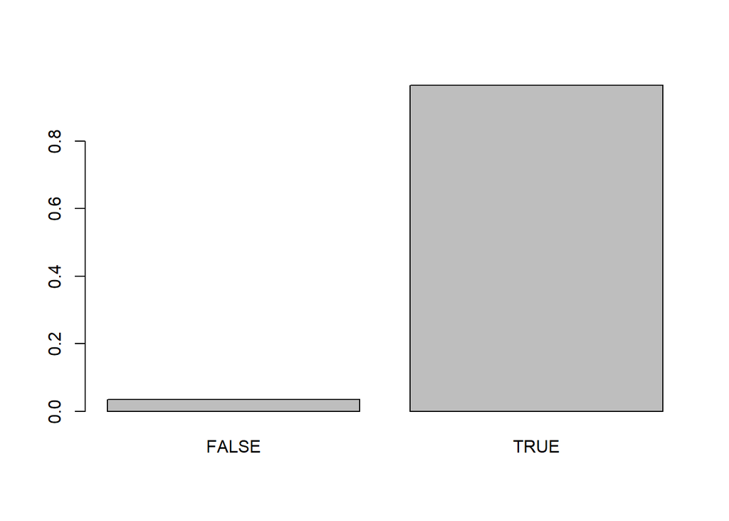

```r
barplot(table(InBornes)/length(InBornes))
```

## 4.6 Quelques tests

### Introduction par la simulation

A l’approche d’une élection mettant en concurrence 2 candidats, un sondage a été réalisé sur 1 000 personnes: celui-ci donne 48,2% d’intentions de votes pour le candidat *A*. En notant $\mathcal{p}_A$ la proportion d’électeurs à voter pour *A* dans la population, on se propose d’examiner l’hypothèse:
$$\mathcal{H}_0 : \mathcal{p}_A = 0.5$$

1. Commenter les instructions suivantes:

```r
table(rbinom(n = 1000, size = 1, prob = 0.8)) # Effectifs de succès et d'échec d'une loi de Bernoulli B(0.8)
table(rbinom(n = 1000, size = 1, prob = 0.8))/1000 # Proportion de succès et d'échec ... de Bernoulli B(0.8)
table(rbinom(n = 1000, size = 1, prob = 0.8))[2]/1000 # Proportion de succès d'une loi de Bernoulli B(0.8)
```

2. En vous aidant des instructions précédentes, simuler les résultats d’un sondage effectué sur 1000 personnes où, dans la population des électeurs, l’hypothèse $\mathcal{H}_0 : \mathcal{p}_A = 0.5$ est vraie

```r
table(rbinom(n = 1000, size = 1, prob = 0.5))[2]/1000
```

```
##     1
## 0.524
```

3. Au moyen d’une boucle (par exemple), simuler (et conserver) les résultats de 100 sondages effectués sur 1000 personnes où, dans la population des électeurs, l’hypothèse $\mathcal{H}_0 : \mathcal{p}_A = 0.5$ est vraie.

*Resultats* : tableau de contingence pour chaque échantillon.

```r
K <- 100
resultats <- matrix(0, K, 2)
```

Boucle sur les $K=100$ sondages

```r
for (k in 1:K){
  echantillon <- rbinom(n = 1000, size = 1, prob = 0.5)
  resultats[k,] <- table(echantillon)
}
```

```r
resultats[,1]/1000
```

Parmis ces resultats, on calcule la fréquence (sur $K$) des probabilités $\leqslant 0.482$

```r
sum( (resultats[,1]/1000) <= 0.482 ) / K
```

```
## [1] 0.13
```

5. Comparer ce résultat à la probabilité critique donnée par l’instruction:

```r
prop.test(x=482, n=1000, p=0.5, alternative = "less")[3] # [3] correspond au p.value dans cette liste
```

```
## $p.value
## [1] 0.1341908
```

### Données **Nile**

On reprend les données **Nile**  
1. Tester la normalité des données.

```r
shapiro.test(Nile)
```

```
##
##  Shapiro-Wilk normality test
##
## data:  Nile
## W = 0.97343, p-value = 0.04072
```

```r
t.test( Nile, mu = 0.950, conf.level = 0.95 )
```

```
##
##  One Sample t-test
##
## data:  Nile
## t = 54.27, df = 99, p-value < 2.2e-16
## alternative hypothesis: true mean is not equal to 0.95
## 95 percent confidence interval:
##  885.7716 952.9284
## sample estimates:
## mean of x
##    919.35
```

2. Test au niveau 99%

```r
t.test( Nile, mu = 0.950, conf.level = 0.99 )
```

```
##
##  One Sample t-test
##
## data:  Nile
## t = 54.27, df = 99, p-value < 2.2e-16
## alternative hypothesis: true mean is not equal to 0.95
## 99 percent confidence interval:
##  874.904 963.796
## sample estimates:
## mean of x
##    919.35
```

```r
t.test( Nile, mu = 0.950, alternative = "greater", conf.level = 0.95 )
```

```
##
##  One Sample t-test
##
## data:  Nile
## t = 54.27, df = 99, p-value < 2.2e-16
## alternative hypothesis: true mean is greater than 0.95
## 95 percent confidence interval:
##  891.2516      Inf
## sample estimates:
## mean of x
##    919.35
```

```r
t.test( Nile, mu = 0.950, alternative = "less", conf.level = 0.95 )
```

```
##
##  One Sample t-test
##
## data:  Nile
## t = 54.27, df = 99, p-value = 1
## alternative hypothesis: true mean is less than 0.95
## 95 percent confidence interval:
##      -Inf 947.4484
## sample estimates:
## mean of x
##    919.35
```

### Indépendance de deux variables qualitatives

L’instruction suivante permet d’obtenir le tableau croisant la couleur des cheveux et la couleur des yeux pour 592 étudiants:

```r
donnees <- margin.table(HairEyeColor, c(1,2))
donnees
```

```
##        Eye
## Hair    Brown Blue Hazel Green
##   Black    68   20    15     5
##   Brown   119   84    54    29
##   Red      26   17    14    14
##   Blond     7   94    10    16
```

1. Obtenir les distributions marginales  
   Distribution marginale de la couleur des yeux, **Eye**, la somme des colonnes

```r
colSums(donnees)
```

```
## Brown  Blue Hazel Green
##   220   215    93    64
```

Distribution marginale de la couleur des cheveux, **Hair**, la somme des lignes

```r
rowSums(donnees)
```

```
## Black Brown   Red Blond
##   108   286    71   127
```

2. Obtenir les distributions conditionnelles

$P(X=i| Y=j)$ est estimée par $n_{ij}/n_{.j}$, alors que $P(Y=j | X=i)$ est estimée par $n_{ij}/n_{i.}$  
**Méthode 1: Méthode directe**

```r
prop.table(donnees, margin = 2)
```

```
##        Eye
## Hair         Brown       Blue      Hazel      Green
##   Black 0.30909091 0.09302326 0.16129032 0.07812500
##   Brown 0.54090909 0.39069767 0.58064516 0.45312500
##   Red   0.11818182 0.07906977 0.15053763 0.21875000
##   Blond 0.03181818 0.43720930 0.10752688 0.25000000
```

**Méthode 2: A la main avec sweep**

```r
nJ <- colSums(donnees)
sweep( donnees, MARGIN = 2, STATS = nJ, FUN = "/")
```

```
##        Eye
## Hair         Brown       Blue      Hazel      Green
##   Black 0.30909091 0.09302326 0.16129032 0.07812500
##   Brown 0.54090909 0.39069767 0.58064516 0.45312500
##   Red   0.11818182 0.07906977 0.15053763 0.21875000
##   Blond 0.03181818 0.43720930 0.10752688 0.25000000
```

**Méthode 3: Avec les matrices**  
On affecte dans une matrice les totaux par colonnes

```r
nJ <- colSums(donnees)
matriceNj <- matrix(nJ, nrow = nrow(donnees), ncol = ncol(donnees), byrow = TRUE)
matriceNj
```

```
##      [,1] [,2] [,3] [,4]
## [1,]  220  215   93   64
## [2,]  220  215   93   64
## [3,]  220  215   93   64
## [4,]  220  215   93   64
```

Et on divise les données par ces sommes

```r
donnees / matriceNj
```

```
##        Eye
## Hair         Brown       Blue      Hazel      Green
##   Black 0.30909091 0.09302326 0.16129032 0.07812500
##   Brown 0.54090909 0.39069767 0.58064516 0.45312500
##   Red   0.11818182 0.07906977 0.15053763 0.21875000
##   Blond 0.03181818 0.43720930 0.10752688 0.25000000
```

3. Tester l’indépendance des deux variables en présence.

```r
chisq.test(donnees)
```

```
##
##  Pearson's Chi-squared test
##
## data:  donnees
## X-squared = 138.29, df = 9, p-value < 2.2e-16
```

4. Obtenir le tableau des valeurs attendues sours l’hypothèse d’indépendance.

On calcule la matrice des $n_{.j}/n$

```r
# Déjà vu plus haut dans la Méthode 3
nJ <- colSums(donnees)
matriceNj <- matrix(nJ, nrow = nrow(donnees), ncol = ncol(donnees), byrow = TRUE)
```

Et la matrice des $n_{i.}/n$

```r
nI <- rowSums(donnees)
matriceNi <- matrix(nI, nrow = nrow(donnees), ncol = ncol(donnees), byrow=FALSE)
matriceNi
```

```
##      [,1] [,2] [,3] [,4]
## [1,]  108  108  108  108
## [2,]  286  286  286  286
## [3,]   71   71   71   71
## [4,]  127  127  127  127
```

La matrice des effectifs attendues $n\times \frac{n_{i.}}{n} \times \frac{n_{.j}}{n}$:

```r
matriceN <- matriceNi * matriceNj / sum(donnees)
matriceN
```

```
##           [,1]      [,2]     [,3]      [,4]
## [1,]  40.13514  39.22297 16.96622 11.675676
## [2,] 106.28378 103.86824 44.92905 30.918919
## [3,]  26.38514  25.78547 11.15372  7.675676
## [4,]  47.19595  46.12331 19.95101 13.729730
```

5. La composante **residuals** de l’objet résultant de la fonction **chisq.test()** donne une indication sur les croisements contribuant le plus aux écarts à l’indépendance: quel croisement est le plus représenté par raport à l’indépendance ? Le moins représenté ?

```r
test <- chisq.test(donnees)
residus <- test$residuals
```

On cherche les résidus les plus faibles (en valeur absolue)

```r
num <- which( abs(residus) == min( abs(residus) ), arr.ind = T)
num
```

```
##     Hair Eye
## Red    3   1
```

```r
paste("Hair:", rownames(donnees)[num[1]], "--Eye:", colnames(donnees)[num[2]])
```

```
## [1] "Hair: Red --Eye: Brown"
```

On cherche les résidus les plus fort (en valeur absolue)

```r
num <- which( abs(residus) == max( abs(residus) ), arr.ind = T)
num
```

```
##       Hair Eye
## Blond    4   2
```

```r
paste("Hair:", rownames(donnees)[num[1]], "--Eye:", colnames(donnees)[num[2]])
```

```
## [1] "Hair: Blond --Eye: Blue"
```

## 4.7 Biais - Variance

L’absence de biais (ou du moins un biais faible) est une des bonnes propriétés que l’on souhaite avoir en estimation. Un estimateur $\hat{\theta}$ d’un paramètre $\theta$ est dit sans biais si $\mathbb{E}[\hat{\theta}] = \theta$. L’espérance mathématique de l’estimateur $\mathbb{E}[\hat{\theta}]$ est la moyenne des estimations, sur tous les échantillons possibles. Ainsi, un estimateur est sans biais lorsque, en moyenne, il tombe sur le paramètre. Une autre propriété souhaitable d’un estimateur est une petite variance. La variance d’un estimateur $\hat{\theta}$ est $var(\hat{\theta}) = \mathbb{E}[(\hat{\theta} - \mathbb{E}[\hat{\theta}])^2]$. Cette quantité mesure, sur tous les échantillons possibles, la moyenne des carrés des écarts entre les estimations et l’espérance de l’estimateur. Ainsi, lorsqu’un estimateur a une petite variance, c’est qu’il y a peu de variabilité entre les estimations possibles : ainsi l’estimation dont on dispose est proche de celles que l’on aurait avec d’autres jeux de données. Examiner les propriétés de biais et variance des estimateurs suppose donc de calculer des espérances, espérances dont le calcul théorique n’est pas toujours simple. La simulation permettant de générer un grand nombre d’estimations, elle autorise à visualiser la distribution de ces estimations donc à illustrer les propriétés des estimateurs et calculer de manière approchée des espérances.

**Deux estimateurs de variance** Pour une suite de variable $X_1,...,X_n$ i.i.d. selon une loi d’espérance commune $\mu$ et de variance $\sigma^2$. On considère deux estimateurs de la variance commune $\sigma^2$:
$$S_n = \frac{1}{n}\sum_{i = 1}^n(X_i - \bar{X})^2 \qquad \qquad \qquad \tilde{S_n} = \frac{1}{n-1}\sum_{i = 1}^n(X_i - \bar{X})^2$$
Comparer les propriétés de biais de ces deux estimateurs de la variance, en prenant la loi de votre choix.

### Maximum des lois uniformes

Soit $U_i,...,U_n$ des variables aléatoires indépendantes de même loi uniforme sur [0, $\theta$]. On envisage deux estimateurs de la borne supérieure $\theta$ de l’intervalle: L’estimateur du maximum de vraisemblance $T_n^{(1)} = 2\bar{X}$ et la plus grande valeur de l’échantillon $T_n^{(2)} = sup (U_i,...,U_n)$.  
1. Générer K échantillons de taille $n=10$ en donnant une valeur à $\theta$

```r
K <- 10000
n <- 10
theta <- 20
resultats <- matrix(0, K, 2)

for (k in 1:K){
  echantillon <- runif(n, max = theta)
  resultats[k,1] <- 2 * mean(echantillon)
  resultats[k,2] <- max(echantillon)
}
```

2. Visualiser la distribution des K estimations de $\theta$ avec chacun des deux estimateurs

```r
colnames(resultats) <- c("T1", "T2") # Nom des colonnes
data.frame(resultats) # Pour un affichage optimal
```

| T1 | T2 |
| --- | --- |
| 25.478241 | 19.922449 |
| 21.301738 | 16.194526 |
| 21.198535 | 19.649839 |
| 18.387317 | 18.644314 |
| 22.547670 | 18.038420 |
| 17.055373 | 19.581845 |
| 17.864885 | 16.356550 |
| 19.748649 | 19.937335 |
| 17.932886 | 17.948105 |
| 19.365872 | 18.182199 |

[output cut: 9990 more lines]

3. Au regard des estimations simulées, comparer les propriétés de biais et de variance des deux estimateurs
1. Calcul du Biais pour les 2 estimateurs

```r
# Méthode 1 : Calcul de la moyenne empirique
Biais = colSums(resultats)/K - theta
Biais
```

```
##          T1          T2
## -0.03884677 -1.81198810
```

```r
# Méthode 2 : Utilisation de apply
Biais = apply(resultats, 2, mean) - theta
```

2. Calcul des Variances des 2 estimateurs

```r
Variance = apply(resultats, 2, var)
Variance
```

```
##        T1        T2
## 13.491353  2.772859
```

4. L’erreur quadratique moyenne d’un estimateur est une mesure de qualité d’un estimateur qui résulte d’un compromis biais-variance. Elle est définie pour un estimateur $\hat{\theta}$ par:
   $$\mathbb{E}[(\hat{\theta} - \theta)^2] = biais^2(\hat{\theta}) + var(\hat{\theta})$$
   Calculer pour les estimateurs $T_n^{(1)}$ et $T_n^{(2)}$ une valeur approchée de cette quantité.

```r
EQ = Biais**2 + Variance
EQ
```

```
##       T1       T2
## 13.49286  6.05616
```

Visionnons graphiquement

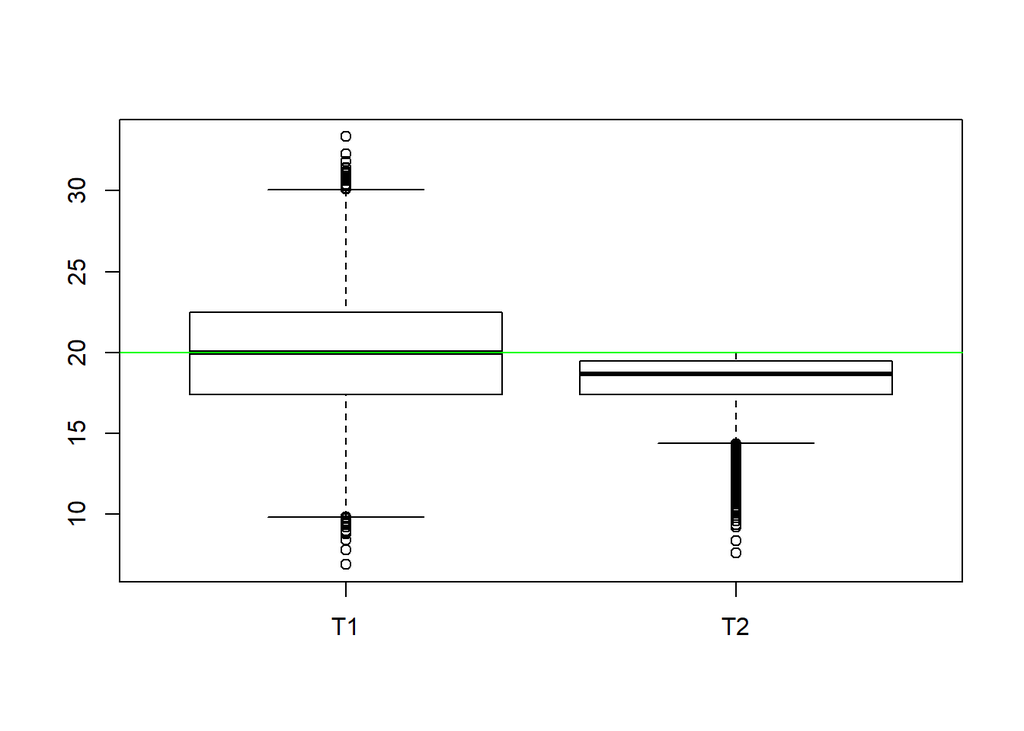

```r
boxplot(resultats)
abline(h = theta, col = "green")
```

# 5. **Régression linéaire simple**

## 5.1 Simulation d’un modèle de régression linéaire simple

On considère le nombre de régression
$$Y_i = \beta_0 + \beta_1 x_i + \epsilon_i, \qquad i = 1,...,n$$
avec les $x_i$ non aléatoires équirépartis sur [0, 1] et les variables $\epsilon_i$ i.i.d. selon une loi $\mathcal{N}(0, \sigma^2)$. Les paramètres ($\beta_0, \beta_1$) et $\sigma^2$ sont inconnus en pratique. Pour illustrer on prend
$$(\beta_0, \beta_1) = (1,2) \qquad \sigma^2 = 0.1$$

1. Simuler des données selon ce modèle

```r
n <- 100
x <- seq(0, 1, length = n)
Beta0 <- 1
Beta1 <- 2
sigma <- 0.1
epsilon <- rnorm(n, mean = 0, sd = sqrt(sigma))

Y <- Beta0 + Beta1 * x + epsilon

data.frame(Y) # Affichage de Y
```

| Y |
| --- |
| 1.0955022 |
| 0.8577811 |
| 0.8983720 |
| 0.5347741 |
| 0.8323273 |
| 1.5042314 |
| 1.3760418 |
| 0.8128945 |
| 1.0235674 |
| 0.8685440 |

[output cut: 90 more lines]

2. Représenter les points ($x_i, Y_i$)

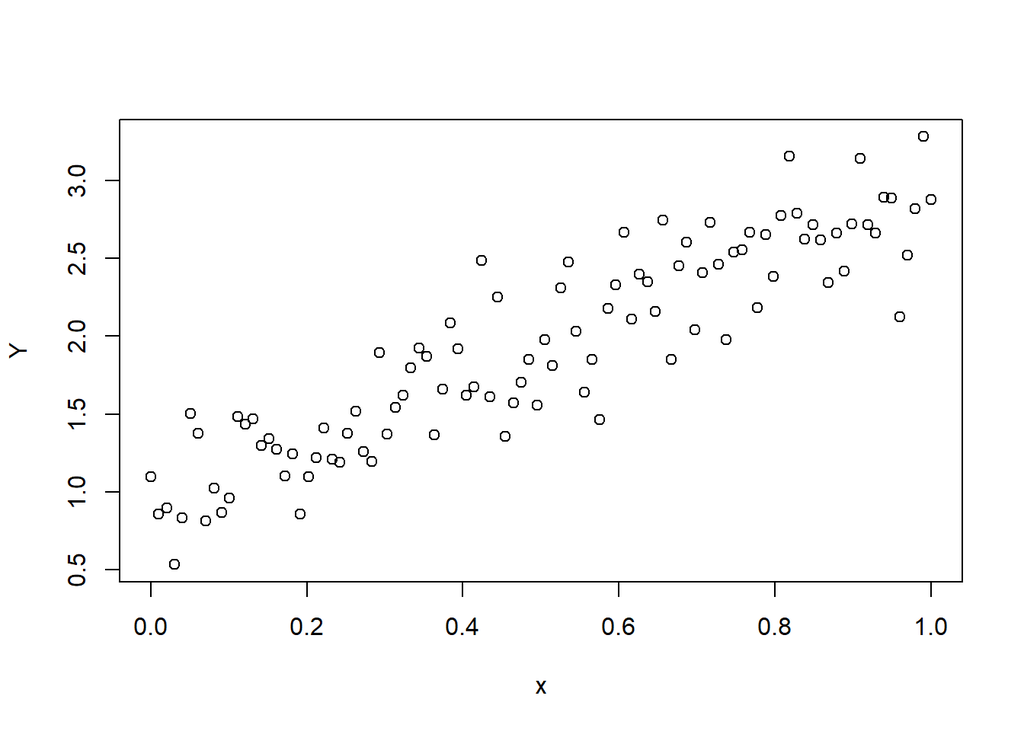

```r
plot(x,Y)
```

3. Sur le même graphique représenter la droite inconnue de paramètre ($\beta_0, \beta_1$)

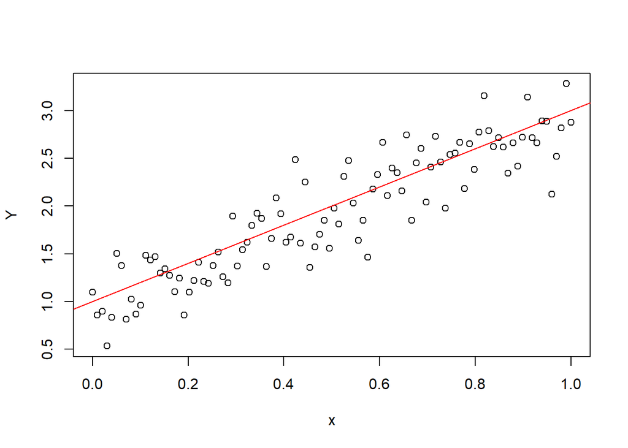

```r
plot(x, Y)
abline(Beta0, Beta1, col = "red")
```

## 5.2 Un estimateur: la droite des points extrêmes

On se propose d’ajuster au nuage la droite passant par les points ($x_i, y_i$) et ($x_n, y_n$) 1. Calculer les paramètres de la droite ajustée par cette méthode L’équation de la droite est de la forme $y_i = ax_i+b$, donc on cherche $a$ et $b$

```r
b = Y[1]
a = Y[n] - Y[1]
```

2. Représenter la droite sur le graphe précédent

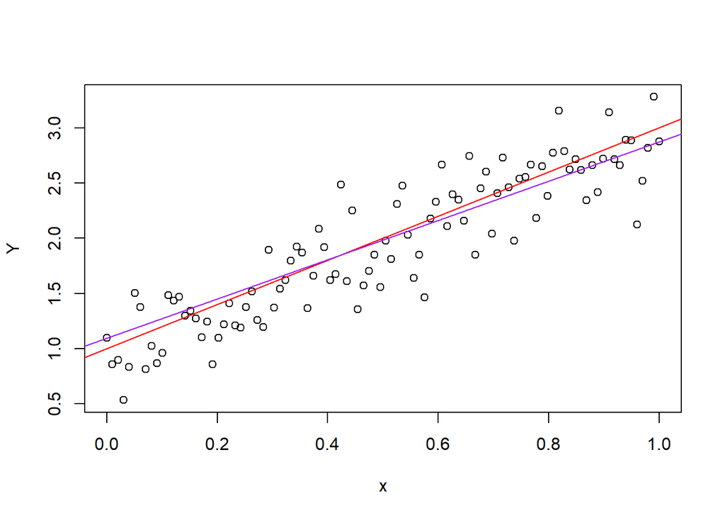

```r
plot(x, Y)
abline(Beta0, Beta1, col = "red") # Question 5.1.3

abline(b, a, col = "purple")
```

3. Calculer l’erreur quadratique moyenne d’ajustement
   $$S(\tilde{\beta_0}, \tilde{\beta_1}) = \frac{1}{n} \sum_{i = 1}^n (y_i - \tilde{y_i})^2$$
   où $\tilde{y_i}$ est la valeur ajustée en $x_i$ par cette méthode.

On calcule $\tilde{Y}$ comme précédemment et l’erreur quadratique moyenne d’ajustement.

```r
tildeY <- b + a * x + epsilon

tilde_EQM <- (1/n) * sum( (Y - tildeY)**2 )
tilde_EQM
```

```
## [1] 0.004415286
```

## 5.3 Un autre estimateur

On considère maintenant la méthode consistant à prendre la droite passant par le point moyen ($\bar{x}, \bar{y}$) et ayant comme pente définie par les points extrêmes. Reprendre les questions de l’exercice précédent avec ce nouvel estimateur.

Calcul des nouveaux coefficients. (On garde le $a$ précédent)

```r
bar_a = a
bar_b = mean(Y) - bar_a * mean(x)
```

Représentation graphique de la droite

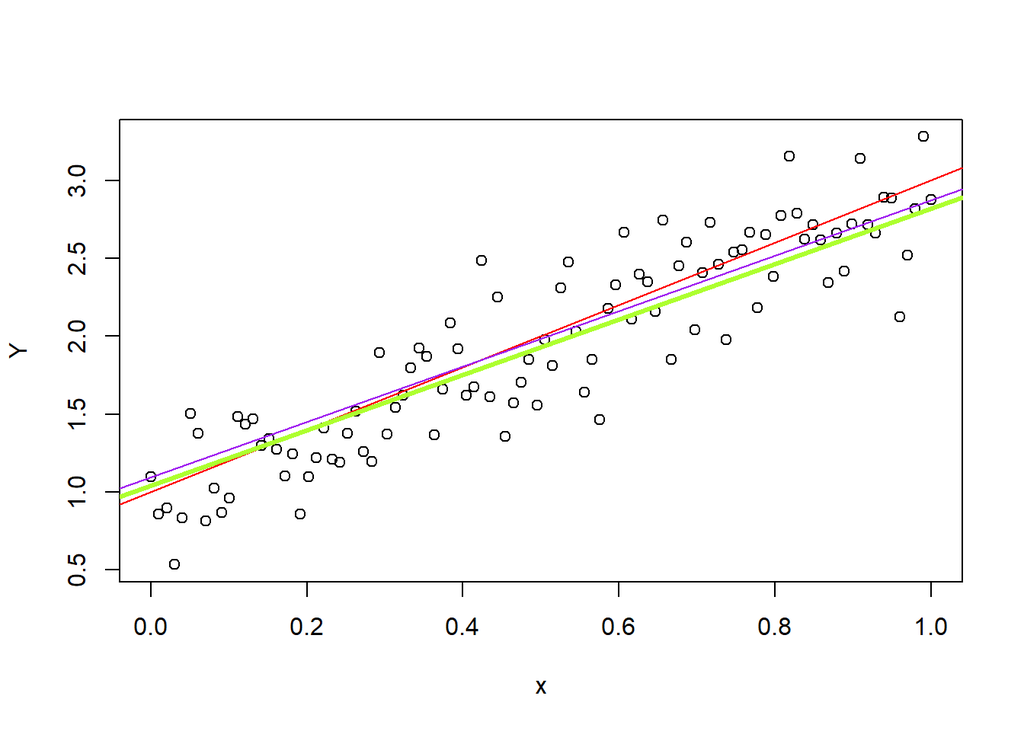

```r
plot(x, Y)
abline(Beta0, Beta1, col = "red") # Question 5.1.3
abline(b, a, col = "purple") # Question 5.2.2

abline(bar_b, bar_a, col = "greenyellow", lwd = 3)
```

Calcul de l’erreur quadratique moyenne d’ajustement

```r
bar_Y <- bar_b + bar_a * x + epsilon

bar_EQM <- (1/n) * sum( (Y - bar_Y)**2 )
bar_EQM
```

```
## [1] 0.0088481
```

Au regard des données, quel ajustement est préférable (au sens quadratique moyen) ? On garde l’ajustement avec l’erreur quadratique moyenne d’ajustement minimal.

```r
min(tilde_EQM, bar_EQM)
```

```
## [1] 0.004415286
```

## 5.4 Estimateur des moindres carrés ordinaires

On rappelle que l’estimateur des moindres carrés est défini par
$$\hat{\beta_1} = \frac{cov(X,Y)}{var(X)} \qquad \hat{\beta_0} = \bar{y} - \hat{\beta_1}\bar{x}$$
où $cov(X,Y)$ et $var(X)$ désignent respectivement covariance et variance empirique.

Reprendre la démarche proposée dans les exercices précédents avec l’estimateur des moindres carrés ordinaires. Quel ajustement est préférable (au sens quadratique moyen) ?

```r
MC_Beta1 <- cov(x, Y) / var(x)
MC_Beta0 <- mean(Y) - MC_Beta1 * mean(x)
```

Représentation graphique de la droite

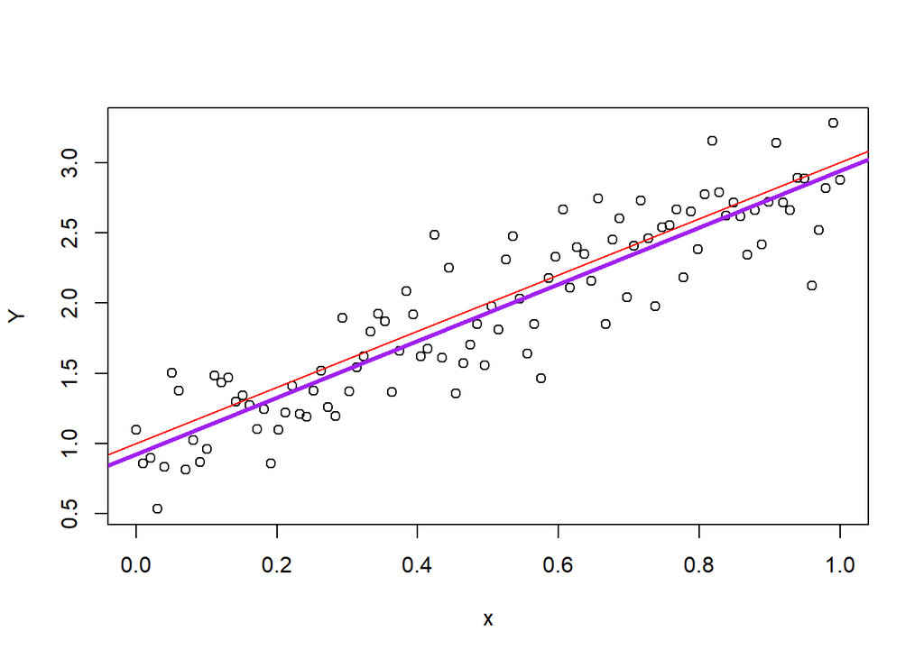

```r
plot(x, Y)
abline(Beta0, Beta1, col = "red") # Question 5.1.3

abline(MC_Beta0, MC_Beta1, col = "purple", lwd = 3)
```

Calcul de l’erreur quadratique moyenne

```r
MC_Y <- MC_Beta0 + MC_Beta1 * x

MC_EQM <- (1/n) * sum( (Y - MC_Y)**2 )
MC_EQM
```

```
## [1] 0.07539944
```

```r
min(tilde_EQM, bar_EQM, MC_EQM)
```

```
## [1] 0.004415286
```

## 5.5 Fonctions **lm**

1. La commande **lm** pour retrouver l’estimation des paramètres par les moindres carrés.

```r
lm(Y~x)
```

```
##
## Call:
## lm(formula = Y ~ x)
##
## Coefficients:
## (Intercept)            x
##      0.9219       2.0195
```

2. Stocker le résultat de la fonction **lm()** dans un objet puis appliquer à cet objet les fonctions : **mode()**, **names()**, **summary()**, **plot()**.

```r
modele <- lm(Y~x)
mode(modele)
```

```
## [1] "list"
```

```r
names(modele)
```

```
##  [1] "coefficients"  "residuals"     "effects"       "rank"
##  [5] "fitted.values" "assign"        "qr"            "df.residual"
##  [9] "xlevels"       "call"          "terms"         "model"
```

```r
summary(modele)
```

```
##
## Call:
## lm(formula = Y ~ x)
##
## Residuals:
##     Min      1Q  Median      3Q     Max
## -0.7357 -0.1780 -0.0184  0.1962  0.7069
##
## Coefficients:
##             Estimate Std. Error t value Pr(>|t|)
## (Intercept)  0.92191    0.05506   16.74   <2e-16 ***
## x            2.01953    0.09513   21.23   <2e-16 ***
## ---
## Signif. codes:  0 '***' 0.001 '**' 0.01 '*' 0.05 '.' 0.1 ' ' 1
##
## Residual standard error: 0.2774 on 98 degrees of freedom
## Multiple R-squared:  0.8214, Adjusted R-squared:  0.8196
## F-statistic: 450.7 on 1 and 98 DF,  p-value: < 2.2e-16
```

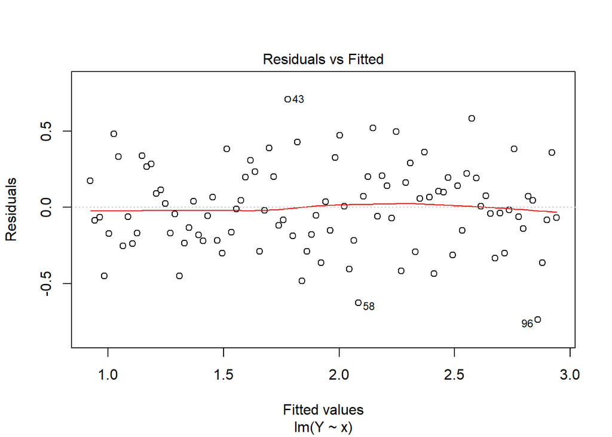

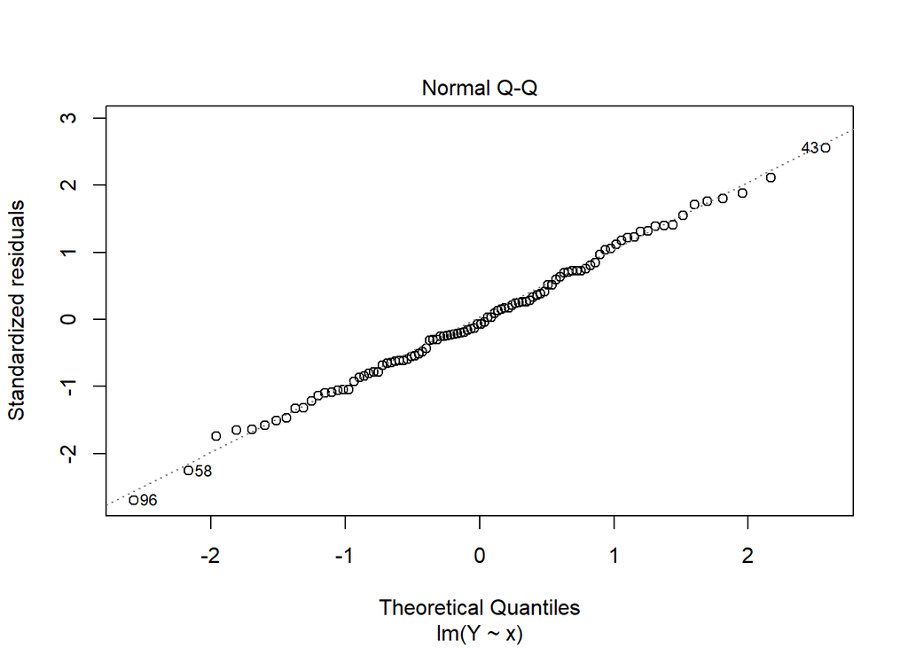

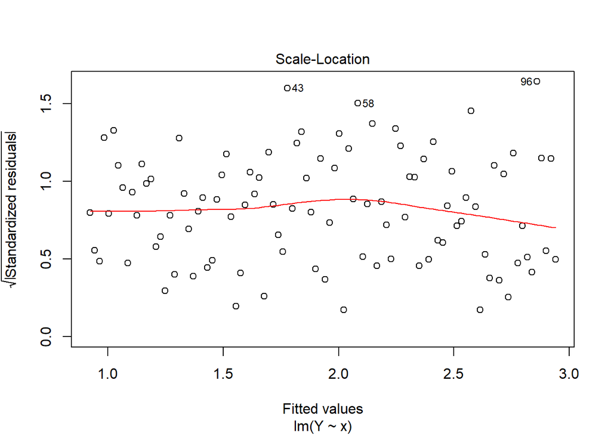

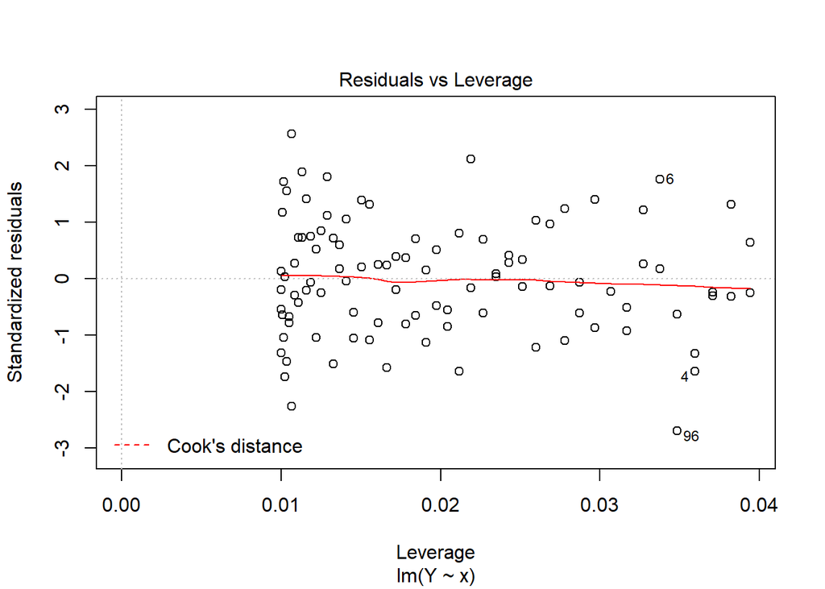

```r
plot(modele)
```

3. Utilisation standard de la fonction **lm()**

Construire un data frame regroupant les observations de $x$ et de $Y$.

```r
observations <- data.frame(Y, x)
```

Retrouver les résultats précédents en utilisant le paramètre *data* de la fonction **lm()**

```r
modele <- lm(data = observations)
summary(modele)
```

```
##
## Call:
## lm(data = observations)
##
## Residuals:
##     Min      1Q  Median      3Q     Max
## -0.7357 -0.1780 -0.0184  0.1962  0.7069
##
## Coefficients:
##             Estimate Std. Error t value Pr(>|t|)
## (Intercept)  0.92191    0.05506   16.74   <2e-16 ***
## x            2.01953    0.09513   21.23   <2e-16 ***
## ---
## Signif. codes:  0 '***' 0.001 '**' 0.01 '*' 0.05 '.' 0.1 ' ' 1
##
## Residual standard error: 0.2774 on 98 degrees of freedom
## Multiple R-squared:  0.8214, Adjusted R-squared:  0.8196
## F-statistic: 450.7 on 1 and 98 DF,  p-value: < 2.2e-16
```

## 5.6 Comparaison d’estimateurs en régression linéaire simple

Dans cet exercice, on se propose de comparer les 3 estimateurs vus précédemment de la pente de la droite de régression dans un modèle de régression linéaire simple.

1. Les instructions qui suivent permettent de simuler $n$ = 100 données $(x_i, y_i)$ selon le modèle $Y_i = \beta_0 + \beta_1 x_i + \epsilon_i$ avec $(\beta_0, \beta_1) = (1,2)$ et les $\epsilon_i$ i.i.d. selon une loi $\mathcal{N}(0, \sigma)$ où $\sigma = 0,5$:

```r
beta0 <- 1 ; beta1 <- 2
n <- 100
sigma <- 0.5
x <- seq(0, 1, length = n)
eps <- rnorm(n, mean = 0, sd = sigma)
y <- beta0 + beta1 * x + eps
```

Représenter les données

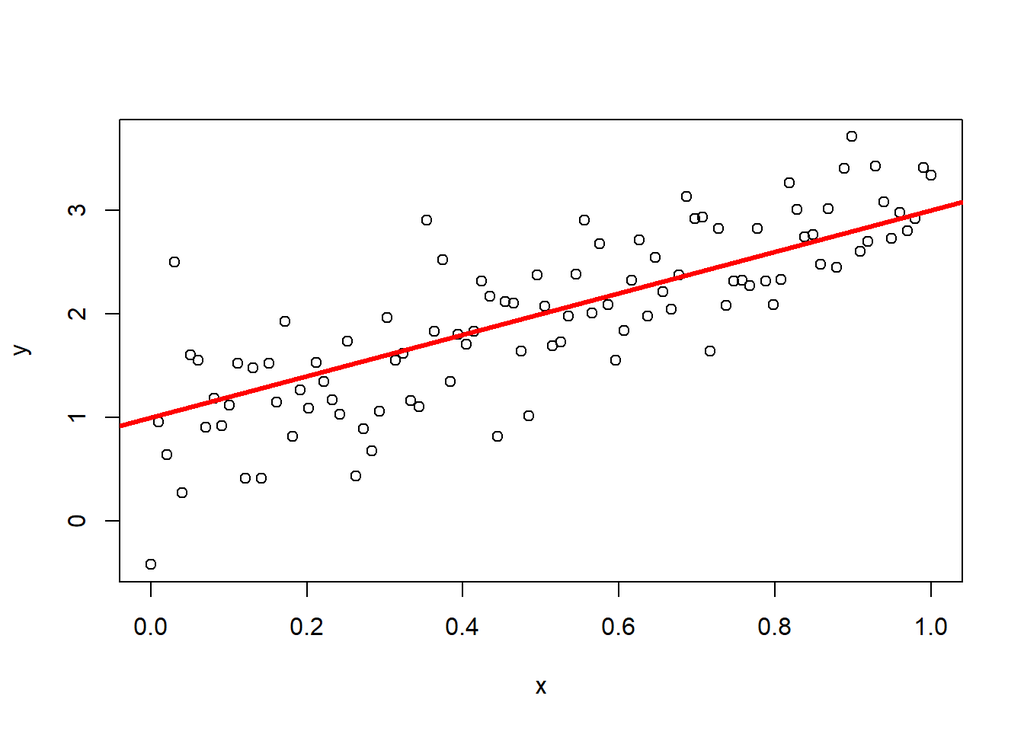

```r
plot(x, y)
abline(beta0, beta1, col = "red", lwd = 3)
```

Calculer l’estimation de $(\beta_0, \beta_1)$ par les 3 méthodes:

- **Points extrêmes**

```r
PE_beta1 <- (y[n] - y[1]) / (x[n] - x[1])
PE_beta0 <- y[1] - PE_beta1 * x[1]

PE_beta0; PE_beta1
```

```
## [1] -0.4175079
```

```
## [1] 3.757448
```

- **Point moyen**

```r
PM_beta1 <- PE_beta1
PM_beta0 <- mean(y) - PM_beta1 * mean(x)

PM_beta0; PM_beta1
```

```
## [1] 0.08922788
```

```
## [1] 3.757448
```

- **Moindre carrés ordinaires**

```r
MC_beta1 <- cov(x,y) / var(x)
MC_beta0 <- mean(y) - MC_beta1 * mean(x)

MC_beta0; MC_beta1
```

```
## [1] 0.8061181
```

```
## [1] 2.323667
```

Tracer les droites associées

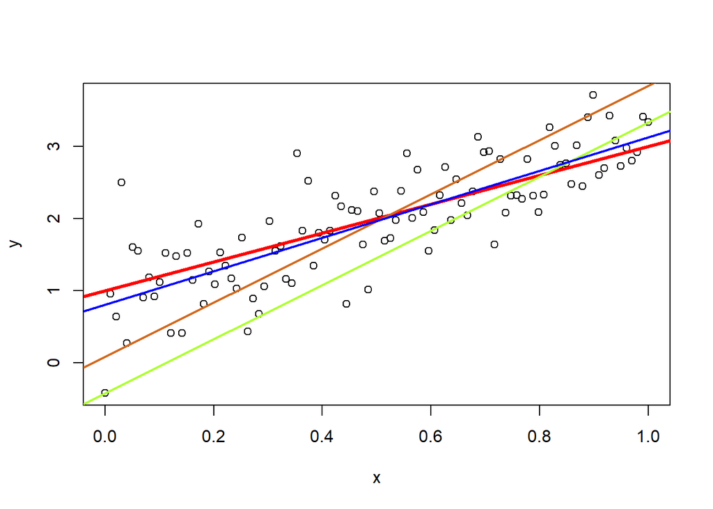

```r
plot(x,y)
abline(beta0, beta1, col = "red", lwd = 3) # Question 5.6.1.a

abline(PE_beta0, PE_beta1, col = "greenyellow", lwd = 2) # Points extrêmes
abline(PM_beta0, PM_beta1, col = "chocolate", lwd = 2) # Point moyen
abline(MC_beta0, MC_beta1, col = "blue", lwd = 2) # Moindre carrés
```

2. Au moyen d’une boucle, simuler $K = 1000$ jeux de données suivant le modèle précédent et stockerles valeurs de pente des 3 estimateurs.

```r
K <- 1000
hat_beta0 <- matrix(0, K, 3)
hat_beta1 <- matrix(0, K, 3)

for (i in 1:K) {
  # Echantillons
  eps <- rnorm(n, mean = 0, sd = sigma)
  y <- beta0 + beta1 * x + eps

  # Points extrêmes
  PE_beta1 <- (y[n] - y[1]) / (x[n] - x[1])
  PE_beta0 <- y[1] - PE_beta1 * x[1]

  # Point moyen
  PM_beta1 <- PE_beta1
  PM_beta0 <- mean(y) - PM_beta1 * mean(x)

  # Moindre carrés ordinaires
  MC_beta1 <- cov(x,y) / var(x)
  MC_beta0 <- mean(y) - MC_beta1 * mean(x)

  # Affectations
  hat_beta1[i,] <- c(PE_beta1, PM_beta1, MC_beta1)
  hat_beta0[i,] <- c(PE_beta0, PM_beta0, MC_beta0)
}
```

Représenter les distributions de ces pentes

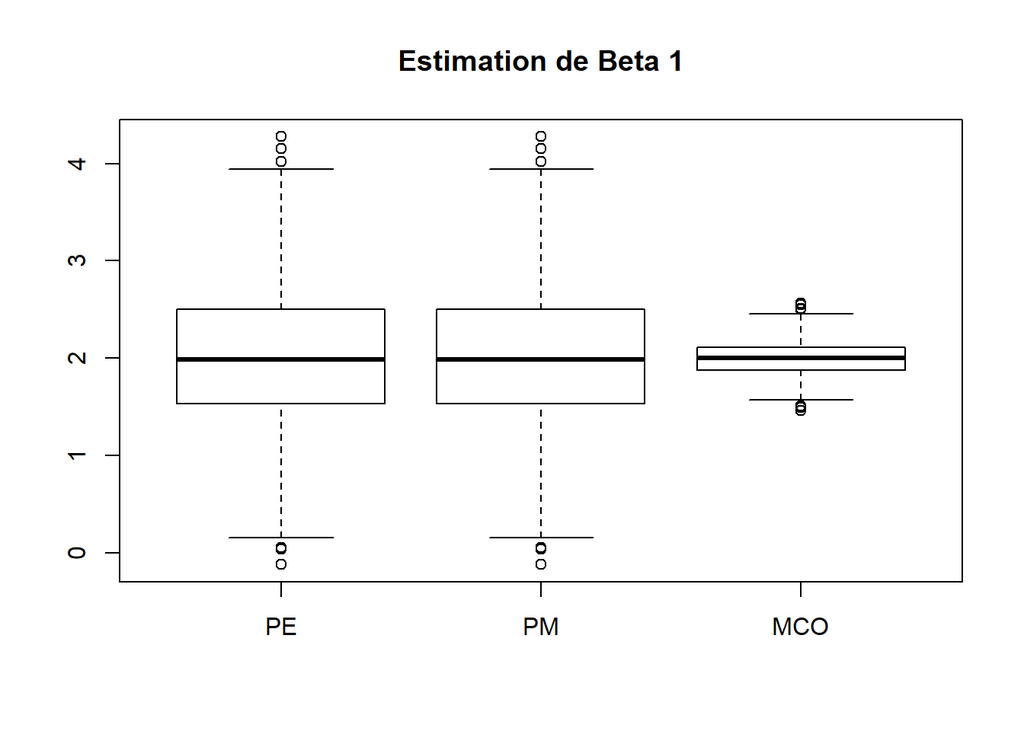

```r
boxplot(hat_beta1, names = c("PE", "PM", "MCO"))
title(main = "Estimation de Beta 1")
```

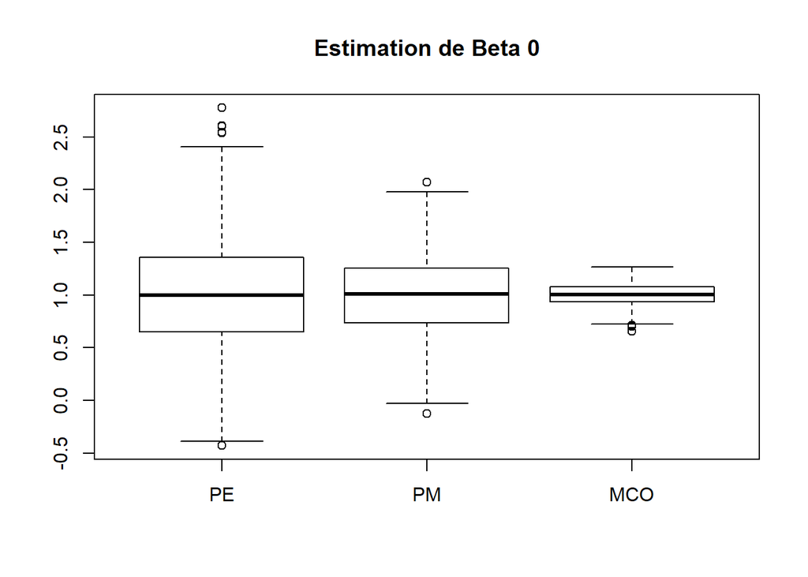

```r
boxplot(hat_beta0, names = c("PE", "PM", "MCO"))
title(main = "Estimation de Beta 0")
```

Evaluer le biais des estimateurs de pente pour les 3 méthodes

```r
apply(hat_beta1, 2, mean) - rep(beta1, 3) # Biais pour les estimations de Beta 1
```

```
## [1]  0.006494389  0.006494389 -0.005792902
```

```r
apply(hat_beta0, 2, mean) - rep(beta0, 3) # Biais pour les estimations de Beta 0
```

```
## [1]  0.012770287 -0.001252328  0.004891318
```

Evaluer la variance des estimateurs de pente pour les 3 méthodes

```r
apply(hat_beta1, 2, var)
```

```
## [1] 0.53777872 0.53777872 0.03042369
```

```r
apply(hat_beta0, 2, var)
```

```
## [1] 0.27071837 0.13571768 0.01036137
```

Evaluer l’EQM

```r
( apply(hat_beta1, 2, mean) - rep(beta1, 3) )^2 + apply(hat_beta1, 2, var)
```

```
## [1] 0.53782090 0.53782090 0.03045724
```

```r
( apply(hat_beta0, 2, mean) - rep(beta0, 3) )^2 + apply(hat_beta0, 2, var)
```

```
## [1] 0.2708814 0.1357193 0.0103853
```

Le troisième estimateur, *MCO*, a l’EQM le plus faible donc on le garde.

## 5.7 Test de nullité d’un coefficient en regréssion linéaire

Dans un modèle de régression linéaire simple
$$Y = \beta_0 + \beta_1 X + \epsilon$$
Les hypothèses sur $\mathbb{E}[\epsilon] = 0$ et $cov(\epsilon_i, \epsilon_j) = 0$ pour $i \neq j$ permettent de justifier de manière théoriques les propriétés d’absence de biais et de faible variance de l’estimateur des moindres carrés. Ces hypothèses ont été implicitement respectées en générant les réalisations de $\epsilon$ dans le modèle simulé en section précédente et les propriétés en découlant ont ainsi été observées.

L’hypothèse de normalité des résidus $\epsilon_i = \mathcal{N}(0, \sigma^2)$ qui est traditionnellement formulée ensuite permet de faire de l’inférence sur les paramètres $\beta_0$ et $\beta_1$ du modèle: tests, calculs d’intervalles de confiance,…

Nous nous focalisons en particulier sur les tests de nullité des paramètres. Par défaut, la colonne **p-value** de la sortie fournie par la fonction **lm()** donne les probabilités critiques associées aux tests
$$\mathcal{H}_0 : \beta_j = 0 \qquad vs \qquad \mathcal{H}_1 : \beta_j \neq 0 \qquad pour \quad j = 0, 1$$

1. Quel est l’intérêt de tester l’hypothèse $\beta_1 = 0$ dans un tel modèle ?
2. Simuler un modèle tel qu’à la section précédente. Faire varier $n, \sigma^2$ ainsi que les valeur du paramètre $\beta_1$ et commenter les probabilités critiques sur le test de nullité de $\beta_1$.

**Modèle A**: n = 100, $\sigma = 0,1$ et $\beta_1 = 2$

```r
K <- 1000
alpha <- 0.05

n.a <- 100
x <- seq(0, 1, length = n.a)
Beta0 <- 0
Beta1.a <- 2
sigma.a <- 0.1
resultat.A <- matrix(0,K)

for (i in 1:K) {
  epsilon <- rnorm(n.a, mean = 0, sd = sigma.a)
  Y <- Beta0 + Beta1.a * x + epsilon
  modele <- lm(Y~x)
  resultat.A[i,] <- summary(modele)$coefficients[2,4]
}

table(resultat.A < alpha) / K
```

```
##
## TRUE
##    1
```

**Modèle B**: n = 100, $\sigma = 0,1$ et $\beta_1 = 0$

```r
Beta1.b <- 0
resultat.B <- matrix(0, K)

for (i in 1:K) {
  epsilon <- rnorm(n.a, mean = 0, sd = sigma.a)
  Y <- Beta0 + Beta1.b * x + epsilon
  modele <- lm(Y~x)
  resultat.B[i,] <- summary(modele)$coefficients[2,4]
}

table(resultat.B < alpha) / K
```

```
##
## FALSE  TRUE
## 0.952 0.048
```

**Modèle C**: n = 50, $\sigma = 1$ et $\beta_1 = 2$

```r
n.c <- 50
x <- seq(0, 1, length = n.c)
Beta1.c <- 2
sigma.c <- 1
resultat.C <- matrix(0, K)

for (i in 1:K) {
  epsilon <- rnorm(n.c, mean = 0, sd = sigma.c)
  Y <- Beta0 + Beta1.c * x + epsilon
  modele <- lm(Y~x)
  resultat.C[i,] <- summary(modele)$coefficients[2,4]
}

table(resultat.C < alpha) / K
```

```
##
## FALSE  TRUE
## 0.019 0.981
```

## 5.8 Régression linéaire sur données réelles: données **ozone**

Les données **ozone** proviennent d’une étude sur les pics de pollution en Bretagne en 2001. Le receuil de ces données avait pour but d’expliquer la pollution de l’air, en construisant en particulier des modèles de prévisions du pic d’ozone du jour (variable de nom **max03**). Le jeu de données renseigne également plusieurs variables potentiellement explicatives, en particulier des variables météo. On s’intéresse en particulier à l’influence des variables

- **T9**, **T12** et **T15** qui donnent les températures du jour à 9h, 12h, 15h;
- **Ne9**, **Ne12** et **Ne15** qui donnent les indices de nébulosité du jour à 9h, 12h, 15h;
- **Vx9**, **Vx12** et **Vx15** qui sont des indicateurs de force du vent du jour à 9h, 12h, 15h.
1. Importer et résumer les données. On précise que les identifiants sont les dates de mesures.

```r
ozone <- read.csv("ozone.txt", row.names = 1, sep = "")
summary(ozone)
```

```
##      maxO3              T9             T12             T15
##  Min.   : 42.00   Min.   :11.30   Min.   :14.00   Min.   :14.90
##  1st Qu.: 70.75   1st Qu.:16.20   1st Qu.:18.60   1st Qu.:19.27
##  Median : 81.50   Median :17.80   Median :20.55   Median :22.05
##  Mean   : 90.30   Mean   :18.36   Mean   :21.53   Mean   :22.63
##  3rd Qu.:106.00   3rd Qu.:19.93   3rd Qu.:23.55   3rd Qu.:25.40
##  Max.   :166.00   Max.   :27.00   Max.   :33.50   Max.   :35.50
##       Ne9             Ne12            Ne15           Vx9
##  Min.   :0.000   Min.   :0.000   Min.   :0.00   Min.   :-7.8785
##  1st Qu.:3.000   1st Qu.:4.000   1st Qu.:3.00   1st Qu.:-3.2765
##  Median :6.000   Median :5.000   Median :5.00   Median :-0.8660
##  Mean   :4.929   Mean   :5.018   Mean   :4.83   Mean   :-1.2143
##  3rd Qu.:7.000   3rd Qu.:7.000   3rd Qu.:7.00   3rd Qu.: 0.6946
##  Max.   :8.000   Max.   :8.000   Max.   :8.00   Max.   : 5.1962
##       Vx12             Vx15            maxO3v          vent      pluie
##  Min.   :-7.878   Min.   :-9.000   Min.   : 42.00   Est  :10   Pluie:43
##  1st Qu.:-3.565   1st Qu.:-3.939   1st Qu.: 71.00   Nord :31   Sec  :69
##  Median :-1.879   Median :-1.550   Median : 82.50   Ouest:50
##  Mean   :-1.611   Mean   :-1.691   Mean   : 90.57   Sud  :21
##  3rd Qu.: 0.000   3rd Qu.: 0.000   3rd Qu.:106.00
##  Max.   : 6.578   Max.   : 5.000   Max.   :166.00
```

2. Calculer la matrice de corrélation entre les variables quantitatives en présence

Les classes des variables dans ozone

```r
sapply(ozone, class)
```

```
##     maxO3        T9       T12       T15       Ne9      Ne12      Ne15
## "integer" "numeric" "numeric" "numeric" "integer" "integer" "integer"
##       Vx9      Vx12      Vx15    maxO3v      vent     pluie
## "numeric" "numeric" "numeric" "integer"  "factor"  "factor"
```

Extraction des variables quantitatives

```r
Qozone <- ozone [ sapply(ozone, class) == "integer"| sapply(ozone, class) == "numeric"]
summary(Qozone)
```

```
##      maxO3              T9             T12             T15
##  Min.   : 42.00   Min.   :11.30   Min.   :14.00   Min.   :14.90
##  1st Qu.: 70.75   1st Qu.:16.20   1st Qu.:18.60   1st Qu.:19.27
##  Median : 81.50   Median :17.80   Median :20.55   Median :22.05
##  Mean   : 90.30   Mean   :18.36   Mean   :21.53   Mean   :22.63
##  3rd Qu.:106.00   3rd Qu.:19.93   3rd Qu.:23.55   3rd Qu.:25.40
##  Max.   :166.00   Max.   :27.00   Max.   :33.50   Max.   :35.50
##       Ne9             Ne12            Ne15           Vx9
##  Min.   :0.000   Min.   :0.000   Min.   :0.00   Min.   :-7.8785
##  1st Qu.:3.000   1st Qu.:4.000   1st Qu.:3.00   1st Qu.:-3.2765
##  Median :6.000   Median :5.000   Median :5.00   Median :-0.8660
##  Mean   :4.929   Mean   :5.018   Mean   :4.83   Mean   :-1.2143
##  3rd Qu.:7.000   3rd Qu.:7.000   3rd Qu.:7.00   3rd Qu.: 0.6946
##  Max.   :8.000   Max.   :8.000   Max.   :8.00   Max.   : 5.1962
##       Vx12             Vx15            maxO3v
##  Min.   :-7.878   Min.   :-9.000   Min.   : 42.00
##  1st Qu.:-3.565   1st Qu.:-3.939   1st Qu.: 71.00
##  Median :-1.879   Median :-1.550   Median : 82.50
##  Mean   :-1.611   Mean   :-1.691   Mean   : 90.57
##  3rd Qu.: 0.000   3rd Qu.: 0.000   3rd Qu.:106.00
##  Max.   : 6.578   Max.   : 5.000   Max.   :166.00
```

Calcul de la matrice de corrélation de **Qozone**

```r
CorOzone <- cor(Qozone)
data.frame(CorOzone) # Affichage
```

|  | maxO3 | T9 | T12 | T15 | Ne9 | Ne12 | Ne15 | Vx9 | Vx12 | Vx15 | maxO3v |
| --- | --- | --- | --- | --- | --- | --- | --- | --- | --- | --- | --- |
| maxO3 | 1.0000000 | 0.6993865 | 0.7842623 | 0.7745700 | -0.6217042 | -0.6407513 | -0.4783021 | 0.5276234 | 0.4307959 | 0.3918989 | 0.6845160 |
| T9 | 0.6993865 | 1.0000000 | 0.8829672 | 0.8464460 | -0.4838636 | -0.4722475 | -0.3251386 | 0.2506896 | 0.2223857 | 0.1703215 | 0.5822451 |
| T12 | 0.7842623 | 0.8829672 | 1.0000000 | 0.9461930 | -0.5842709 | -0.6601002 | -0.4580991 | 0.4301045 | 0.3126291 | 0.2706802 | 0.5636289 |
| T15 | 0.7745700 | 0.8464460 | 0.9461930 | 1.0000000 | -0.5861683 | -0.6492261 | -0.5746817 | 0.4530892 | 0.3437506 | 0.2866028 | 0.5678887 |
| Ne9 | -0.6217042 | -0.4838636 | -0.5842709 | -0.5861683 | 1.0000000 | 0.7883411 | 0.5502490 | -0.4976361 | -0.5287752 | -0.4939010 | -0.2765500 |
| Ne12 | -0.6407513 | -0.4722475 | -0.6601002 | -0.6492261 | 0.7883411 | 1.0000000 | 0.7098668 | -0.4926581 | -0.5103204 | -0.4322695 | -0.3619227 |
| Ne15 | -0.4783021 | -0.3251386 | -0.4580991 | -0.5746817 | 0.5502490 | 0.7098668 | 1.0000000 | -0.4014717 | -0.4318633 | -0.3782896 | -0.3084755 |
| Vx9 | 0.5276234 | 0.2506896 | 0.4301045 | 0.4530892 | -0.4976361 | -0.4926581 | -0.4014717 | 1.0000000 | 0.7501775 | 0.6822608 | 0.3403172 |
| Vx12 | 0.4307959 | 0.2223857 | 0.3126291 | 0.3437506 | -0.5287752 | -0.5103204 | -0.4318633 | 0.7501775 | 1.0000000 | 0.8371720 | 0.2236755 |
| Vx15 | 0.3918989 | 0.1703215 | 0.2706802 | 0.2866028 | -0.4939010 | -0.4322695 | -0.3782896 | 0.6822608 | 0.8371720 | 1.0000000 | 0.1899220 |

[output cut: 1 more lines]

3. Proposer une méthodologie pour déterminer la “meilleure” variable explicative quantitative dans une modèle de regréssion linéaire simple.

La meilleure variable explicative est la variable ayant la corrélation maximale avec **max03**.

```r
which( abs(CorOzone[-1,1]) == max( abs(CorOzone[-1,1]) ) )
```

```
## T12
##   2
```

La “meilleure” variable explicative est **T12**.

## 5.9 Une mesure de la qualité de l’ajustement: R²

Dans un modèle de régression linéaire, si on note $Y_i$ les observations de la variable à expliquer et $\hat{Y}_i = \hat{\beta}_0 + \hat{\beta}_1 X_i$ les valeurs ajustées, le coefficient dit de détermination, noté $R^2$, est défini par:
$$R^2 = \frac{var(\hat{Y})}{var(Y)}$$
Ce coefficient, compris entre 0 et 1 mesure la qualité d’ajustement du modèle: plus il est proche de 1 et plus les points du nuage sont proches de la droite ajustée.

On continue avec les données **ozone**

1. Retrouver les sorties associées au modèle linéaire liant **maxO3** et **T12**

On teste le modèle: **maxO3** = 1 + **T12**

```r
modele <- lm(maxO3 ~ 1 + T12, data = ozone)
resume <- summary( modele )
resume
```

```
##
## Call:
## lm(formula = maxO3 ~ 1 + T12, data = ozone)
##
## Residuals:
##     Min      1Q  Median      3Q     Max
## -38.079 -12.735   0.257  11.003  44.671
##
## Coefficients:
##             Estimate Std. Error t value Pr(>|t|)
## (Intercept) -27.4196     9.0335  -3.035    0.003 **
## T12           5.4687     0.4125  13.258   <2e-16 ***
## ---
## Signif. codes:  0 '***' 0.001 '**' 0.01 '*' 0.05 '.' 0.1 ' ' 1
##
## Residual standard error: 17.57 on 110 degrees of freedom
## Multiple R-squared:  0.6151, Adjusted R-squared:  0.6116
## F-statistic: 175.8 on 1 and 110 DF,  p-value: < 2.2e-16
```

2. Retrouver dans les sorties la valeur de $R^2$.

Le coefficient de détermination $R^2$ et sa valeur ajustée sont, respectivement, le 8e et le 9e élément de la sortie du modèle.

```r
data.frame(resume[8], resume[9]) # data.frame pour affichage
```

| r.squared | adj.r.squared |
| --- | --- |
| 0.6150674 | 0.611568 |

## 5.10 Données **ozone**: influence de **T12** selon les conditions de pluie

Le fichier **ozone** enseigne également la variable **pluie**, variable qualitative qui indique s’il pleuvait ou pas lejour de la mesure.

1. Représenter dans un même nuage de points les variables **maxO3** et **T12** en introduisant un code couleur permettant de distinguer les observations de la variable **pluie**.

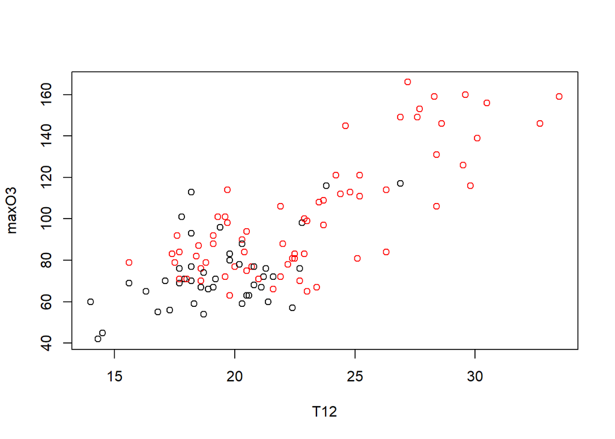

```r
plot(maxO3 ~ 1+T12, col = pluie, data = ozone)
```

2. Ajuster les droites de régression obtenues selon les conditions de pluie.

On sépare les données dans une liste selon les modalités de **pluie**, ensuite on affecte à la variable *modele* la sortie du modèle linéaire liant **maxO3** et **T12** aux deux éléments de la liste.

```r
Pluie_Sec <- split( ozone[, c("maxO3","T12")], list(ozone$pluie) )
modele <- lapply(Pluie_Sec, FUN = function(donnees) {return( lm(maxO3 ~ T12, data = donnees) )} )

lapply(modele, FUN = summary) # Affichage du résumé pour chaque modalité
```

```
## $Pluie
##
## Call:
## lm(formula = maxO3 ~ T12, data = donnees)
##
## Residuals:
##     Min      1Q  Median      3Q     Max
## -27.137 -10.607  -1.630   7.565  43.319
##
## Coefficients:
##             Estimate Std. Error t value Pr(>|t|)
## (Intercept)   7.0386    17.5636   0.401 0.690687
## T12           3.4419     0.9033   3.810 0.000457 ***
## ---
## Signif. codes:  0 '***' 0.001 '**' 0.01 '*' 0.05 '.' 0.1 ' ' 1
##
## Residual standard error: 14.94 on 41 degrees of freedom
## Multiple R-squared:  0.2615, Adjusted R-squared:  0.2435
## F-statistic: 14.52 on 1 and 41 DF,  p-value: 0.0004574
##
##
## $Sec
##
## Call:
## lm(formula = maxO3 ~ T12, data = donnees)
##
## Residuals:
##     Min      1Q  Median      3Q     Max
## -36.357 -11.978   0.141  11.596  42.406
##
## Coefficients:
##             Estimate Std. Error t value Pr(>|t|)
## (Intercept) -21.2601    12.2970  -1.729   0.0884 .
## T12           5.3255     0.5278  10.091 4.44e-15 ***
## ---
## Signif. codes:  0 '***' 0.001 '**' 0.01 '*' 0.05 '.' 0.1 ' ' 1
##
## Residual standard error: 18.19 on 67 degrees of freedom
## Multiple R-squared:  0.6031, Adjusted R-squared:  0.5972
## F-statistic: 101.8 on 1 and 67 DF,  p-value: 4.445e-15
```

On trace la droite de régression pour chacune des modalités

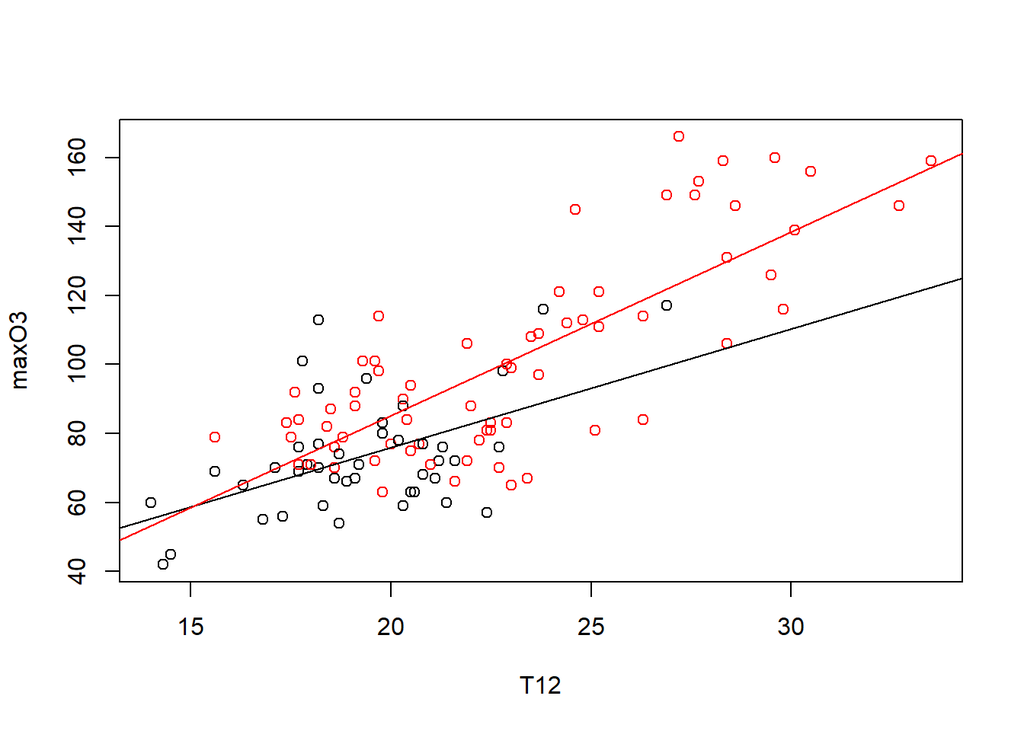

[figure not shown]

```r
plot(maxO3 ~ 1+T12, col = pluie, data = ozone) # Question 5.10.1

abline( coef(modele$Pluie) )
abline( coef(modele$Sec), col = "red")
```